# Nature Use Survey Analysis

Wangda Zhu

2021-04-05

# DATA WRANGLING

This is a workflow of analyzing survey data from Qualtrics. When exporting data from Qualtrics, make sure to select “Use choice text” and “Split multi-value fields into columns” and export the data as csv file.

After downloading the file, open it and delete the first **two rows** of the raw data. Now you should have the spreadsheet with only one row as its head. This will give convenience to further data wrangling in R.

## Import useful libraries and read the raw data to R

```r
library(tidyverse)
library(vcd)
library(vcdExtra)
library(gmodels) #SPSS tables

raw<-read_csv("rawdata2.csv")
names(raw)<-str_replace_all(names(raw), c("#" = "."))
colnames(raw)[5]<-"Duration"
colnames(raw)[9]<-"Distribution"
raw$StartDate<-as.Date(raw$StartDate,format='%m/%d/%y')
```

## Filter the valid sample by progress, distribution, duration and startdate

```r
raw<-raw[raw$StartDate>"2020-11-23",]
raw<-raw[raw$Progress>70 & raw$Duration>180 & raw$Distribution != "preview",]
raw0<-raw
```

## 1 we create new dataframes for each multichoice questions and count the number of checked boxes

```r
#Q2.3 nature access
Q2.3<- raw %>%
  select(contains( "Q2.3")) %>%
  mutate(private=ifelse(is.na(Q2.3_1),0,1)) %>%
  mutate(deck=ifelse(is.na(Q2.3_2),0,1)) %>%
  mutate(public=ifelse(is.na(Q2.3_5),0,1)) %>%
  mutate(botanical=ifelse(is.na(Q2.3_7),0,1)) %>%
  mutate(nature=ifelse(is.na(Q2.3_8),0,1)) %>%
  mutate(woodland=ifelse(is.na(Q2.3_9),0,1)) %>%
  mutate(river=ifelse(is.na(Q2.3_10),0,1)) %>%
  mutate(lake=ifelse(is.na(Q2.3_11),0,1)) %>%
  mutate(none=ifelse(is.na(Q2.3_14),0,1)) %>%
  mutate(other=ifelse(is.na(Q2.3_14),0,1)) %>%
  select(-contains("Q2.3")) %>%
  mutate(access.score=private+deck+public+botanical+nature+woodland+river+lake+other)
Q2.3<-Q2.3 %>%
  mutate(outdoorsathome=private+deck) %>%
  mutate(outdoorsnearhome=(public+botanical+nature+woodland+river+lake+other)) %>%
  mutate(divesitynearhome=ifelse(outdoorsnearhome>=3,1,0))

#Q2.4 nature use type before and after
Q2.4.before<- raw %>%
  select(contains( "Q2.4")) %>%
  mutate(private=ifelse(is.na(Q2.4.1_1_1),0,1)) %>%
  mutate(deck=ifelse(is.na(Q2.4.1_2_1),0,1)) %>%
  mutate(public=ifelse(is.na(Q2.4.1_3_1),0,1)) %>%
  mutate(botanical=ifelse(is.na(Q2.4.1_4_1),0,1)) %>%
  mutate(nature=ifelse(is.na(Q2.4.1_5_1),0,1)) %>%
  mutate(woodland=ifelse(is.na(Q2.4.1_6_1),0,1)) %>%
  mutate(river=ifelse(is.na(Q2.4.1_7_1),0,1)) %>%
  mutate(lake=ifelse(is.na(Q2.4.1_8_1),0,1)) %>%
  mutate(none=ifelse(is.na(Q2.4.1_10_1),0,1)) %>%
  select(-contains("Q2.4")) %>%
  mutate(use.score.before=private+deck+public+botanical+nature+woodland+river+lake)

Q2.4.after<- raw %>%
  select(contains( "Q2.4")) %>%
  mutate(private=ifelse(is.na(Q2.4.1_1_2),0,1)) %>%
  mutate(deck=ifelse(is.na(Q2.4.1_2_2),0,1)) %>%
  mutate(public=ifelse(is.na(Q2.4.1_3_2),0,1)) %>%
  mutate(botanical=ifelse(is.na(Q2.4.1_4_2),0,1)) %>%
  mutate(nature=ifelse(is.na(Q2.4.1_5_2),0,1)) %>%
  mutate(woodland=ifelse(is.na(Q2.4.1_6_2),0,1)) %>%
  mutate(river=ifelse(is.na(Q2.4.1_7_2),0,1)) %>%
  mutate(lake=ifelse(is.na(Q2.4.1_8_2),0,1)) %>%
  mutate(none=ifelse(is.na(Q2.4.1_10_2),0,1)) %>%
  select(-contains("Q2.4")) %>%
  mutate(use.score.after=private+deck+public+botanical+nature+woodland+river+lake)

#Q3.2 nature use activity before and after
Q3.2<- raw %>%
  select(contains( "Q3.2")) %>%
  mutate(social_before=ifelse(is.na(Q3.2_1_1),0,1)) %>%
  mutate(social_during=ifelse(is.na(Q3.2_1_2),0,1)) %>%
  mutate(lowintensity_before=ifelse(is.na(Q3.2_2_1),0,1)) %>%
  mutate(lowintensity_during=ifelse(is.na(Q3.2_2_2),0,1)) %>%
  mutate(highintensity_before=ifelse(is.na(Q3.2_3_1),0,1)) %>%
  mutate(highintensity_during=ifelse(is.na(Q3.2_3_2),0,1)) %>%
  mutate(restorative_before=ifelse(is.na(Q3.2_4_1),0,1)) %>%
  mutate(restorative_during=ifelse(is.na(Q3.2_4_2),0,1)) %>%
  mutate(others_before=ifelse(is.na(Q3.2_5_1),0,1)) %>%
  mutate(others_during=ifelse(is.na(Q3.2_5_2),0,1)) %>%
  select(-contains("Q3.2")) %>%
  mutate(total_before=social_before + lowintensity_before + highintensity_before + restorative_before + others_before) %>%
  mutate(total_during=social_during + lowintensity_during + highintensity_during + restorative_during + others_during)

#Q3.3 nature use companion before and after
Q3.3<- raw %>%
  select(contains( "Q3.3")) %>%
  mutate(myself_before=ifelse(is.na(Q3.3_1_1),0,1)) %>%
  mutate(myself_during=ifelse(is.na(Q3.3_1_2),0,1)) %>%
  mutate(family_before=ifelse(is.na(Q3.3_2_1),0,1)) %>%
  mutate(family_during=ifelse(is.na(Q3.3_2_2),0,1)) %>%
  mutate(friends_before=ifelse(is.na(Q3.3_3_1),0,1)) %>%
  mutate(friends_during=ifelse(is.na(Q3.3_3_2),0,1)) %>%
  mutate(workmates_before=ifelse(is.na(Q3.3_4_1),0,1)) %>%
  mutate(workmates_during=ifelse(is.na(Q3.3_4_2),0,1)) %>%
  mutate(others_before=ifelse(is.na(Q3.3_5_1),0,1)) %>%
  mutate(others_during=ifelse(is.na(Q3.3_5_2),0,1)) %>%
  select(-contains("Q3.3")) %>%
  mutate(total_before=myself_before + family_before + friends_before + workmates_before + others_before) %>%
  mutate(total_during=myself_during + family_during + friends_during + workmates_during + others_during)

#Q4.2 nature use reason before and after
Q4.2<- raw %>%
  select(contains( "Q4.2")) %>%
  mutate(exercise_before=ifelse(is.na(Q4.2_1_1),0,1)) %>%
  mutate(exercise_during=ifelse(is.na(Q4.2_1_2),0,1)) %>%
  mutate(stressrelief_before=ifelse(is.na(Q4.2_2_1),0,1)) %>%
  mutate(stressrelief_during=ifelse(is.na(Q4.2_2_2),0,1)) %>%
  mutate(fun_before=ifelse(is.na(Q4.2_3_1),0,1)) %>%
  mutate(fun_during=ifelse(is.na(Q4.2_3_2),0,1)) %>%
  mutate(nature_before=ifelse(is.na(Q4.2_4_1),0,1)) %>%
  mutate(nature_during=ifelse(is.na(Q4.2_4_2),0,1)) %>%
  mutate(family_before=ifelse(is.na(Q4.2_5_1),0,1)) %>%
  mutate(family_during=ifelse(is.na(Q4.2_5_2),0,1)) %>%
  mutate(friends_before=ifelse(is.na(Q4.2_6_1),0,1)) %>%
  mutate(friends_during=ifelse(is.na(Q4.2_6_2),0,1)) %>%
  mutate(others_before=ifelse(is.na(Q4.2_7_1),0,1)) %>%
  mutate(others_during=ifelse(is.na(Q4.2_7_2),0,1)) %>%
  select(-contains("Q4.2")) %>%
  mutate(total_before=exercise_before + stressrelief_before + fun_before + nature_before +friends_before + family_before+ others_before) %>%
  mutate(total_during=exercise_during + stressrelief_during + fun_during + nature_during +friends_during + family_during+ others_during)

#Q4.5 nature access barriers
Q4.5<- raw %>%
  select(contains( "Q4.5")) %>%
  mutate(notime=ifelse(is.na(Q4.5_3),0,1)) %>%
  mutate(noaccess=ifelse(is.na(Q4.5_4),0,1)) %>%
  mutate(unsafe=ifelse(is.na(Q4.5_7),0,1)) %>%
  mutate(noones=ifelse(is.na(Q4.5_8),0,1)) %>%
  mutate(others=ifelse(is.na(Q4.5_9),0,1)) %>%
  select(-contains("Q4.5")) %>%
  mutate(total_barries=notime + noaccess + unsafe + noones + others)

#Q5.6 nature work use activity
Q5.6<- raw %>%
  select(contains( "Q5.6")) %>%
  mutate(eat=ifelse(is.na(Q5.6_1),0,1)) %>%
  mutate(walk=ifelse(is.na(Q5.6_2),0,1)) %>%
  mutate(meet=ifelse(is.na(Q5.6_3),0,1)) %>%
  mutate(rest=ifelse(is.na(Q5.6_4),0,1)) %>%
  mutate(others=ifelse(is.na(Q5.6_5),0,1)) %>%
  select(-contains("Q5.6")) %>%
  mutate(total_campusoutdoors=eat + walk + meet + rest + others)

#Q5.7 nature work access barrier
Q5.7<- raw %>%
  select(contains( "Q5.7")) %>%
  mutate(nointerest=ifelse(is.na(Q5.7_1),0,1)) %>%
  mutate(notime=ifelse(is.na(Q5.7_2),0,1)) %>%
  mutate(discouraged=ifelse(is.na(Q5.7_3),0,1)) %>%
  mutate(noaccess=ifelse(is.na(Q5.7_4),0,1)) %>%
  mutate(unappealing=ifelse(is.na(Q5.7_9),0,1)) %>%
  mutate(noprotect=ifelse(is.na(Q5.7_10),0,1)) %>%
  mutate(others=ifelse(is.na(Q5.7_11),0,1)) %>%
  select(-contains("Q5.7")) %>%
  mutate(total_barriers=nointerest+notime+discouraged+noaccess+unappealing+noprotect + others)

#Q6.2 household
Q6.2<- raw %>%
  select(contains( "Q6.2")) %>%
  mutate(self=ifelse(is.na(Q6.2_10),0,1)) %>%
  mutate(childpre=ifelse(is.na(Q6.2_1),0,1)) %>%
  mutate(childele=ifelse(is.na(Q6.2_2),0,1)) %>%
  mutate(youthmiddle=ifelse(is.na(Q6.2_3),0,1)) %>%
  mutate(youthhigh=ifelse(is.na(Q6.2_4),0,1)) %>%
  mutate(partner=ifelse(is.na(Q6.2_5),0,1)) %>%
  mutate(parents=ifelse(is.na(Q6.2_6),0,1)) %>%
  mutate(otherfamily=ifelse(is.na(Q6.2_7),0,1)) %>%
  mutate(friend=ifelse(is.na(Q6.2_8),0,1)) %>%
  mutate(others=ifelse(is.na(Q6.2_9),0,1)) %>%
  select(-contains("Q6.2")) %>%
  mutate(total_household=childpre+childele+youthhigh+youthmiddle+partner+parents+otherfamily+friend + others) %>%
  mutate(children=(childpre==1|childele==1|youthmiddle==1|youthhigh==1))

# Q6.4 family outdoor activities
Q6.4<- raw %>%
  select(contains( "Q6.4")) %>%
  mutate(walking=ifelse(is.na(Q6.4_2),0,1)) %>%
  mutate(running=ifelse(is.na(Q6.4_3),0,1)) %>%
  mutate(kayaking=ifelse(is.na(Q6.4_5),0,1)) %>%
  mutate(gardening=ifelse(is.na(Q6.4_6),0,1)) %>%
  mutate(relaxing=ifelse(is.na(Q6.4_7),0,1)) %>%
  mutate(camping=ifelse(is.na(Q6.4_9),0,1)) %>%
  mutate(fishing=ifelse(is.na(Q6.4_10),0,1)) %>%
  mutate(others=ifelse(is.na(Q6.4_11),0,1)) %>%
  select(-contains("Q6.4")) %>%
  mutate(total_familyoutdoors=walking+running+kayaking+gardening+relaxing+camping+fishing + others)
```

## 2 we recode some variables and group them with the same measurement

```r
#time natureQ2.4, Q2.6, Q2.7, Q2.8, Q2.10
timeoutdoors<- raw %>%
  dplyr:: select(contains(c("2.5", "2.6", "2.7","2.8", "2.10"))) %>%
  mutate_at(vars(1),function(x)(dplyr::recode(x,"7 days"=7, "4-6 days" = 5,
                                                "2-3 days" = 2.5,"1 day" = 1,
                                                "No days" = 0))) %>%
  mutate_at(vars(2),function(x)(dplyr::recode(x,"More than 1 hr"=60, "31min - 1hr" = 45,
                                              "15-30 min" = 22.5,"Less than 15 min" = 7.5)))

#Q4.3 How you feel after time in nature
Q4.3<- raw %>%
  select(contains("4.3")) %>%
  mutate_at(vars(1:5),function(x)(dplyr::recode(x,"Strongly agree"=5, "Somewhat agree" = 4,
                                                "Neither agree nor disagree" = 3,"Somewhat disagree" = 2,
                                                "Strongly disagree" = 1)))
Q4.3$score=rowMeans(cbind(Q4.3$Q4.3_1,Q4.3$Q4.3_2,Q4.3$Q4.3_3,Q4.3$Q4.3_4,Q4.3$Q4.3_5),na.rm = TRUE)

#Q4.4 – How do you generally feel about nature
Q4.4<- raw %>%
  select(contains("4.4")) %>%
  mutate_at(vars(1:3),function(x)(dplyr::recode(x,"Not at all"=0, "Somewhat" = 1,
                                                "Definitely" = 3)))
Q4.4$score=rowMeans(cbind(Q4.4$Q4.4_1,Q4.4$Q4.4_2,Q4.4$Q4.4_3),na.rm = TRUE)

#Q6.5 Spending time with family in nature
Q6.5<- raw %>%
  select(contains("6.5")) %>%
  mutate_at(vars(1:5),function(x)(dplyr::recode(x,"Strongly agree"=5, "Somewhat agree" = 4,
                                                "Neither agree nor disagree" = 3,"Somewhat disagree" = 2,
                                                "Strongly disagree" = 1)))
Q6.5$score=rowMeans(cbind(Q6.5$Q6.5_1,Q6.5$Q6.5_2,Q6.5$Q6.5_3),na.rm = TRUE)

Q7.7_access<- raw %>%
  mutate(private=ifelse(is.na(Q2.3_1),0,1)) %>%
  mutate(deck=ifelse(is.na(Q2.3_2),0,1)) %>%
  mutate(public=ifelse(is.na(Q2.3_5),0,1)) %>%
  mutate(botanical=ifelse(is.na(Q2.3_7),0,1)) %>%
  mutate(nature=ifelse(is.na(Q2.3_8),0,1)) %>%
  mutate(woodland=ifelse(is.na(Q2.3_9),0,1)) %>%
  mutate(river=ifelse(is.na(Q2.3_10),0,1)) %>%
  mutate(lake=ifelse(is.na(Q2.3_11),0,1)) %>%
  mutate(other=ifelse(is.na(Q2.3_13),0,1)) %>%
  mutate(none=ifelse(is.na(Q2.3_14),0,1)) %>%
  mutate(access.score=private+deck+public+botanical+nature+woodland+river+lake+other) %>%
  select(contains("Q7.7"),access.score)
Q7.7_access<- Q7.7_access %>%
  mutate(neighborhood=dplyr::recode(Q7.7,"Larger city or urban center (e.g., Syracuse, NYC)"=5,
                                              "Smaller city or urban center (e.g. Ithaca, Elmira)" = 4,
                                              "Suburb or just outside an urban center (e.g, Cayuga Heights, East Ithaca)" = 3,
                                              "Small town or village (e.g., Trumansburg, Lansing)" = 2,
                                              "Rural area" = 1))

# Q7.8 – Ethnicity / race
Q7.8<- raw %>%
  select(contains( "Q7.8")) %>%
  mutate(race2=case_when(is.na(Q7.8_1)==FALSE | is.na(Q7.8_2)==FALSE | is.na(Q7.8_3)==FALSE ~ "1",
                           is.na(Q7.8_4)==FALSE | is.na(Q7.8_5)==FALSE ~ "2",
                           is.na(Q7.8_6)==FALSE  ~ "3",
                           is.na(Q7.8_7)==FALSE  ~ "4",
                           is.na(Q7.8_8)==FALSE ~ "NA")) %>%
  mutate(race1=case_when(is.na(Q7.8_1)==FALSE ~ "1",
                         is.na(Q7.8_2)==FALSE~ "2",
                         is.na(Q7.8_3)==FALSE~ "3",
                        is.na(Q7.8_4)==FALSE  ~ "4",
                        is.na(Q7.8_5)==FALSE~ "5",
                        is.na(Q7.8_6)==FALSE  ~ "6",
                        is.na(Q7.8_7)==FALSE  ~ "7",
                        is.na(Q7.8_8)==FALSE ~ "NA")) %>%
  select(-contains("Q7.8")) %>%
  mutate_if(is.character, as.factor)
```

## 3 we visulize some basic data

```r
Q2.3 %>%
  ggplot(mapping = aes(x=as.factor(access.score))) +
  geom_bar(stat="count",position='dodge')
```

```r
Q2.3 %>%
  ggplot(mapping = aes(x=as.factor(outdoorsathome))) +
  geom_bar(stat="count",position='dodge')
```

```r
Q2.3 %>%
  ggplot(mapping = aes(x=as.factor(outdoorsnearhome))) +
  geom_bar(stat="count",position='dodge')
```

```r
Q2.3 %>%
  ggplot(mapping = aes(x=as.factor(divesitynearhome))) +
  geom_bar(stat="count",position='dodge')
```

```r
timeoutdoors %>%
  ggplot(mapping = aes(x=as.factor(Q2.7))) +
  geom_bar(stat="count",position='dodge')+
  xlab("Weekend days – compared to weekdays ")
```

```r
timeoutdoors %>%
  ggplot(mapping = aes(x=as.factor(Q2.8))) +
  geom_bar(stat="count",position='dodge')+
  xlab("Fall 2020 Vs April-July2020")
```

```r
timeoutdoors %>%
  ggplot(mapping = aes(x=as.factor(Q2.10))) +
  geom_bar(stat="count",position='dodge')+
  xlab("Fall 2020 Vs Fall 2019")
```

```r
Q3.2 %>%
  pivot_longer(total_before:total_during,
               names_to = "time",
               values_to = "number") %>%
  ggplot(mapping = aes(x=number,fill=time)) +
  geom_bar(stat="count",position='dodge')
```

```r
Q3.2 %>%
  pivot_longer(social_before:others_during,
               names_to = "activity",
               values_to = "number") %>%
  group_by(activity) %>%
  summarise_all(sum) %>%
  ggplot(mapping = aes(x=activity,y=number)) +
  geom_bar(stat="identity")+
  theme(axis.text.x = element_text(size=10,angle = 90,hjust=.5,vjust=.5,face="plain"))
```

```r
Q3.3 %>%
  pivot_longer(total_before:total_during,
               names_to = "time",
               values_to = "number") %>%
  ggplot(mapping = aes(x=number,fill=time)) +
  geom_bar(stat="count",position='dodge')
```

```r
Q3.3 %>%
  pivot_longer(myself_before:others_during,
               names_to = "people",
               values_to = "number") %>%
  group_by(people) %>%
  summarise_all(sum) %>%
  ggplot(mapping = aes(x=people,y=number)) +
  geom_bar(stat="identity")+
  theme(axis.text.x = element_text(size=10,angle = 90,hjust=.5,vjust=.5,face="plain"))
```

```r
Q5.6 %>%
  pivot_longer(eat:others,
               names_to = "activities",
               values_to = "number") %>%
  group_by(activities) %>%
  summarise_all(sum) %>%
  ggplot(mapping = aes(x=activities,y=number)) +
  geom_bar(stat="identity")
```

## 4 we visulize before and after multi choice questions, we take Q2.4 for example

```r
Q2.4<- raw %>%
  select(contains( "Q2.4")) %>%
  mutate(private=case_when(is.na(Q2.4.1_1_1)==TRUE & is.na(Q2.4.1_1_2)==TRUE ~ 1,
                           is.na(Q2.4.1_1_1)==TRUE & is.na(Q2.4.1_1_2)==FALSE ~ 2,
                           is.na(Q2.4.1_1_1)==FALSE & is.na(Q2.4.1_1_2)==TRUE ~ 3,
                           is.na(Q2.4.1_1_1)==FALSE & is.na(Q2.4.1_1_2)==FALSE ~ 4)) %>%
  mutate(deck=case_when(is.na(Q2.4.1_2_1)==TRUE & is.na(Q2.4.1_2_2)==TRUE ~ 1,
                           is.na(Q2.4.1_2_1)==TRUE & is.na(Q2.4.1_2_2)==FALSE ~ 2,
                           is.na(Q2.4.1_2_1)==FALSE & is.na(Q2.4.1_2_2)==TRUE ~ 3,
                           is.na(Q2.4.1_2_1)==FALSE & is.na(Q2.4.1_2_2)==FALSE ~ 4)) %>%
  mutate(public=case_when(is.na(Q2.4.1_3_1)==TRUE & is.na(Q2.4.1_3_2)==TRUE ~ 1,
                           is.na(Q2.4.1_3_1)==TRUE & is.na(Q2.4.1_3_2)==FALSE ~ 2,
                           is.na(Q2.4.1_3_1)==FALSE & is.na(Q2.4.1_3_2)==TRUE ~ 3,
                           is.na(Q2.4.1_3_1)==FALSE & is.na(Q2.4.1_3_2)==FALSE ~ 4)) %>%
  mutate(botanical=case_when(is.na(Q2.4.1_4_1)==TRUE & is.na(Q2.4.1_4_2)==TRUE ~ 1,
                           is.na(Q2.4.1_4_1)==TRUE & is.na(Q2.4.1_4_2)==FALSE ~ 2,
                           is.na(Q2.4.1_4_1)==FALSE & is.na(Q2.4.1_4_2)==TRUE ~ 3,
                           is.na(Q2.4.1_4_1)==FALSE & is.na(Q2.4.1_4_2)==FALSE ~ 4)) %>%
  mutate(nature=case_when(is.na(Q2.4.1_5_1)==TRUE & is.na(Q2.4.1_5_2)==TRUE ~ 1,
                           is.na(Q2.4.1_5_1)==TRUE & is.na(Q2.4.1_5_2)==FALSE ~ 2,
                           is.na(Q2.4.1_5_1)==FALSE & is.na(Q2.4.1_5_2)==TRUE ~ 3,
                           is.na(Q2.4.1_5_1)==FALSE & is.na(Q2.4.1_5_2)==FALSE ~ 4)) %>%
  mutate(woodland=case_when(is.na(Q2.4.1_6_1)==TRUE & is.na(Q2.4.1_6_2)==TRUE ~ 1,
                           is.na(Q2.4.1_6_1)==TRUE & is.na(Q2.4.1_6_2)==FALSE ~ 2,
                           is.na(Q2.4.1_6_1)==FALSE & is.na(Q2.4.1_6_2)==TRUE ~ 3,
                           is.na(Q2.4.1_6_1)==FALSE & is.na(Q2.4.1_6_2)==FALSE ~ 4)) %>%
  mutate(river=case_when(is.na(Q2.4.1_7_1)==TRUE & is.na(Q2.4.1_7_2)==TRUE ~ 1,
                           is.na(Q2.4.1_7_1)==TRUE & is.na(Q2.4.1_7_2)==FALSE ~ 2,
                           is.na(Q2.4.1_7_1)==FALSE & is.na(Q2.4.1_7_2)==TRUE ~ 3,
                           is.na(Q2.4.1_7_1)==FALSE & is.na(Q2.4.1_7_2)==FALSE ~ 4)) %>%
  mutate(lake=case_when(is.na(Q2.4.1_8_1)==TRUE & is.na(Q2.4.1_8_2)==TRUE ~ 1,
                           is.na(Q2.4.1_8_1)==TRUE & is.na(Q2.4.1_8_2)==FALSE ~ 2,
                           is.na(Q2.4.1_8_1)==FALSE & is.na(Q2.4.1_8_2)==TRUE ~ 3,
                           is.na(Q2.4.1_8_1)==FALSE & is.na(Q2.4.1_8_2)==FALSE ~ 4)) %>%
  mutate(none=case_when(is.na(Q2.4.1_10_1)==TRUE & is.na(Q2.4.1_10_2)==TRUE ~ 1,
                           is.na(Q2.4.1_10_1)==TRUE & is.na(Q2.4.1_10_2)==FALSE ~ 2,
                           is.na(Q2.4.1_10_1)==FALSE & is.na(Q2.4.1_10_2)==TRUE ~ 3,
                           is.na(Q2.4.1_10_1)==FALSE & is.na(Q2.4.1_10_2)==FALSE ~ 4)) %>%
  select(-contains("Q2.4"))

Q2.4 %>%
  pivot_longer(private:none,
               names_to = "place",
               values_to = "change") %>%
  mutate(change=factor(change,labels = c("NbeforeNnow", "beforeNnow","Nbeforenow","beforenow"))) %>%
  ggplot(mapping = aes(x=place,fill=change)) +
    geom_bar(stat="count",position='dodge')
```

```r
Q2.4.score<-cbind(Q2.4.before,Q2.4.after)

Q2.4.score %>%
  select(use.score.before,use.score.after) %>%
  pivot_longer(use.score.before:use.score.after,
               names_to = "time",
               values_to = "number") %>%
  ggplot(mapping = aes(x=number,fill=factor(time,levels = c("use.score.before","use.score.after")))) +
  geom_bar(stat="count",position='dodge')+
  guides(fill=guide_legend(title="Time"))+
  ggtitle("Plot of total types of place use before and after COVID")
```

```r
Q2.4.before<-Q2.4.before %>%
  pivot_longer(private:none,
               names_to = "place",
               values_to = "use") %>%
  group_by(place) %>%
  dplyr::summarise(se = sd(use)/sqrt(483),total = sum(use)) %>%
  mutate(time="before")


Q2.4.after<-Q2.4.after %>%
  pivot_longer(private:none,
               names_to = "place",
               values_to = "use") %>%
  group_by(place) %>%
  dplyr::summarise(se = sd(use)/sqrt(483),total = sum(use)) %>%
  mutate(time="after")

Q2.4.sum<-rbind(Q2.4.before,Q2.4.after)
levels<-unique(Q2.4.sum$place)
Q2.4.sum$place<-factor(Q2.4.sum$place,levels = c("botanical","deck","lake","nature","private","public","river","woodland","none"))
Q2.4.sum %>%
  ggplot(mapping = aes(x=place,y=total/483,fill=factor(time,levels = c("before","after")))) +
  geom_bar(stat="identity",position='dodge')+
  geom_errorbar(aes(ymin=total/483-se, ymax=total/483+se), width=.5,
                position=position_dodge(.9)) +
  ylab("proportion")+
  guides(fill=guide_legend(title="Time"))+
  ggtitle("Plot of place use before and after COVID")
```

```r
###Let's focus on the change: who change most after covid?
Q2.4.score %>%
  select(use.score.before,use.score.after) %>%
  mutate(change=use.score.after-use.score.before) %>%
  select(change) %>%
  mutate(id = row_number()) %>%
  ggplot(mapping = aes(x = id,y=change))+
  geom_bar(stat = "identity")
```

```r
Q2.4_demo<-Q2.4.score %>%
  select(use.score.before,use.score.after) %>%
  mutate(change=use.score.after-use.score.before) %>%
  select(change) %>%
  mutate(id = row_number()) %>%
  mutate(largechange=ifelse(change>2 | change <(-2),1,0)) %>%
  mutate(changedirection=case_when(change>0~"positive",
                                   change==0~"nochange",
                                   change<0~"negative")) %>%
  cbind("neighborhood"=raw$Q7.7) %>%
  cbind("gender"= raw$Q7.2) %>%
  cbind("workplace"=raw$Q5.3) %>%
  cbind("workyear"= raw$Q7.3)


Q2.4_demo %>% ggplot(mapping = aes(x=neighborhood,fill=factor(largechange)))+
  geom_bar(stat="count",position = "dodge")
```

```r
Q2.4_demo %>% ggplot(mapping = aes(x=neighborhood,fill=factor(changedirection)))+
  geom_bar(stat="count",position = "dodge")
```

```r
Q2.4_demo %>% ggplot(mapping = aes(x=gender,fill=factor(changedirection)))+
  geom_bar(stat="count",position = "dodge")
```

```r
Q2.4_demo %>% ggplot(mapping = aes(x=workplace,fill=factor(changedirection)))+
  geom_bar(stat="count",position = "dodge")+
  theme(axis.text.x = element_text(size=10,angle = 20,hjust=.5,vjust=.5,face="plain"))
```

```r
Q2.4_demo %>% ggplot(mapping = aes(x=workyear,fill=factor(changedirection)))+
  geom_bar(stat="count",position = "dodge")+
  theme(axis.text.x = element_text(size=10,angle = 20,hjust=.5,vjust=.5,face="plain"))
```

## 5 we do basic correlation calculation for continous, ordinal and binary data, there are different sorts of correlations between different types of variables

```r
#correlatio between spend time outdoors during the workday,
#gender(0/1), how long at cornell, neighborhood type,
#household total, children, feel1, feel2, work barriers total,
#time in nature, spend time outdoors during the workday
raw$Q5.2<-dplyr::recode(raw$Q5.2,"0 days"=0, "1 day"  = 1,
              "2-3 days" = 2,"4-5 days" = 3)
raw$Q7.2<-dplyr::recode(raw$Q7.2,"Female"=0, "Male"  = 1)
raw$Q7.3<-dplyr::recode(raw$Q7.3,"Less than 2 years"=0,
                        "More than 2 but less than 5 years"  = 1,
                        "More than 5 but less than 10 years" = 2,
                        "10 or more years" =3)
raw$Q7.7<-dplyr::recode(raw$Q7.7,"Larger city or urban center (e.g., Syracuse, NYC)"=1,
                 "Smaller city or urban center (e.g. Ithaca, Elmira)" = 1,
                 "Suburb or just outside an urban center (e.g, Cayuga Heights, East Ithaca)" = 0,
                 "Small town or village (e.g., Trumansburg, Lansing)" = 0,
                 "Rural area" = 0)
Q6.2<- raw %>%
    select(contains( "Q6.2")) %>%
    mutate(self=ifelse(is.na(Q6.2_10),0,1)) %>%
    mutate(childpre=ifelse(is.na(Q6.2_1),0,1)) %>%
    mutate(childele=ifelse(is.na(Q6.2_2),0,1)) %>%
    mutate(youthmiddle=ifelse(is.na(Q6.2_3),0,1)) %>%
    mutate(youthhigh=ifelse(is.na(Q6.2_4),0,1)) %>%
    mutate(partner=ifelse(is.na(Q6.2_5),0,1)) %>%
    mutate(parents=ifelse(is.na(Q6.2_6),0,1)) %>%
    mutate(otherfamily=ifelse(is.na(Q6.2_7),0,1)) %>%
    mutate(friend=ifelse(is.na(Q6.2_8),0,1)) %>%
    mutate(others=ifelse(is.na(Q6.2_9),0,1)) %>%
    select(-contains("Q6.2")) %>%
    mutate(total_household=childpre+childele+youthhigh+youthmiddle+partner+parents+otherfamily+friend + others) %>%
    mutate(children=(childpre==1|childele==1|youthmiddle==1|youthhigh==1))
Q6.2$children<-ifelse(Q6.2$children==TRUE,1,0)
Q4.3<- raw %>%
    select(contains("4.3")) %>%
    mutate_at(vars(1:5),function(x)(dplyr::recode(x,"Strongly agree"=5, "Somewhat agree" = 4,
                                                  "Neither agree nor disagree" = 3,"Somewhat disagree" = 2,
                                                  "Strongly disagree" = 1)))
Q4.3$score=rowMeans(cbind(Q4.3$Q4.3_1,Q4.3$Q4.3_2,Q4.3$Q4.3_3,Q4.3$Q4.3_4,Q4.3$Q4.3_5),na.rm = TRUE)
Q4.4<- raw %>%
    select(contains("4.4")) %>%
    mutate_at(vars(1:3),function(x)(dplyr::recode(x,"Not at all"=0, "Somewhat" = 1,
                                                  "Definitely" = 3)))
Q4.4$score=rowMeans(cbind(Q4.4$Q4.4_1,Q4.4$Q4.4_2,Q4.4$Q4.4_3),na.rm = TRUE)
Q5.7<- raw %>%
    select(contains( "Q5.7")) %>%
    mutate(nointerest=ifelse(is.na(Q5.7_1),0,1)) %>%
    mutate(notime=ifelse(is.na(Q5.7_2),0,1)) %>%
    mutate(discouraged=ifelse(is.na(Q5.7_3),0,1)) %>%
    mutate(noaccess=ifelse(is.na(Q5.7_4),0,1)) %>%
    mutate(unappealing=ifelse(is.na(Q5.7_9),0,1)) %>%
    mutate(noprotect=ifelse(is.na(Q5.7_10),0,1)) %>%
    mutate(others=ifelse(is.na(Q5.7_11),0,1)) %>%
    select(-contains("Q5.7")) %>%
    mutate(total_barriers=nointerest+notime+discouraged+noaccess+unappealing+noprotect + others)

raw$Q2.5<-dplyr::recode(raw$Q2.5,"7 days"=4, "4-6 days" = 3,
                                            "2-3 days" = 2,"1 day" = 1,
                                            "No days" = 0)
raw$Q2.6<-dplyr::recode(raw$Q2.6,"More than 1 hr"=3, "31min - 1hr" = 2,
                                  "15-30 min" = 1,"Less than 15 min" = 0)
df.cor<-as.data.frame(cbind(raw$Q5.2,raw$Q7.2,raw$Q7.3,raw$Q7.7,Q6.2$total_household,Q6.2$children,Q4.4$score,Q4.3$score,Q5.7$total_barriers,raw$Q2.5,raw$Q2.6))
colnames(df.cor)<-c("out_week","gender","workyrs","neighbor","household","children","naturefeel","nature_after_feel","barriers","week_out","out_time")
round(cor(df.cor,use="pairwise.complete.obs"),digits =3)
ltm::rcor.test(df.cor,use="pairwise.complete.obs")
```

## 6 we do basic statistic tests for norminal,ordinal and binary data such as chi2 test

```r
# Q1
#CORRELATION BETWEEN ORDINAL AND ORDINAL
#                    ORDINAL AND NORMINAL
#                    NORMINAL AND NORMINAL
#1. CHI-2 TEST CAN BE USED
# We check space use and space access

df.chi<-Q2.3 %>%
  select(access.score,outdoorsathome,outdoorsnearhome,divesitynearhome) %>%
  mutate(access.score=as.factor(access.score)) %>%
  rename(access=access.score) %>%
  mutate(outdoorsathome=as.factor(outdoorsathome)) %>%
  mutate(outdoorsnearhome=as.factor(outdoorsnearhome)) %>%
  mutate(divesitynearhome=as.factor(divesitynearhome)) %>%
  cbind("use.types.before"=as.factor(Q2.4.score$use.score.before)) %>%
  cbind("use.types.after"=as.factor(Q2.4.score$use.score.after)) %>%
  cbind("neighborhood"=as.factor(raw$Q7.7)) %>%
  cbind("gender"= as.factor(raw$Q7.2)) %>%
  cbind("workyear"= as.factor(raw$Q7.3)) %>%
  cbind("use.activities.before"= as.factor(Q3.2$total_before)) %>%
  cbind("use.activities.after"= as.factor(Q3.2$total_during)) %>%
  cbind("use.companions.before"= as.factor(Q3.3$total_before)) %>%
  cbind("use.companions.after"= as.factor(Q3.3$total_during)) %>%
  cbind("time.daysperweek"=as.factor(raw$Q2.5)) %>%
  cbind("time.hourspertime"=as.factor(raw$Q2.6)) %>%
  cbind("race1"=Q7.8$race1) %>%
  cbind("race2"=Q7.8$race2)



#access
mapply(function(x, y) chisq.test(x, y)$p.value, df.chi[, -1], MoreArgs=list(df.chi[,1]))
#outdoorsathome
mapply(function(x, y) chisq.test(x, y)$p.value, df.chi[, -2], MoreArgs=list(df.chi[,2]))
#outdoorsnearhome
mapply(function(x, y) chisq.test(x, y)$p.value, df.chi[, -3], MoreArgs=list(df.chi[,3]))
#divesitynearhome
mapply(function(x, y) chisq.test(x, y)$p.value, df.chi[, -4], MoreArgs=list(df.chi[,4]))
#neighborhood
mapply(function(x, y) chisq.test(x, y)$p.value, df.chi[, -7], MoreArgs=list(df.chi[,7]))
#gender
mapply(function(x, y) chisq.test(x, y)$p.value, df.chi[, -8], MoreArgs=list(df.chi[,8]))
#time week
mapply(function(x, y) chisq.test(x, y)$p.value, df.chi[, -14], MoreArgs=list(df.chi[,14]))
#time hour
mapply(function(x, y) chisq.test(x, y)$p.value, df.chi[, -15], MoreArgs=list(df.chi[,15]))

# We check work/campus based space use

df.chi2<-Q5.6 %>%
  select(total_campusoutdoors) %>%
  mutate(total_campusoutdoors=as.factor(total_campusoutdoors)) %>%
  cbind("timeinworkday"=as.factor(raw$Q5.2)) %>%
  cbind("use.types.before"=as.factor(Q2.4.score$use.score.before)) %>%
  cbind("use.types.after"=as.factor(Q2.4.score$use.score.after)) %>%
  cbind("neighborhood"=as.factor(raw$Q7.7)) %>%
  cbind("gender"= as.factor(raw$Q7.2)) %>%
  cbind("workyear"= as.factor(raw$Q7.3)) %>%
  cbind("use.activities.before"= as.factor(Q3.2$total_before)) %>%
  cbind("use.activities.after"= as.factor(Q3.2$total_during)) %>%
  cbind("use.companions.before"= as.factor(Q3.3$total_before)) %>%
  cbind("use.companions.after"= as.factor(Q3.3$total_during)) %>%
  cbind("time.daysperweek"=as.factor(raw$Q2.5)) %>%
  cbind("time.hourspertime"=as.factor(raw$Q2.6)) %>%
  cbind("race1"=Q7.8$race1) %>%
  cbind("race2"=Q7.8$race2)

#total_campusoutdoors
mapply(function(x, y) chisq.test(x, y)$p.value, df.chi2[, -1], MoreArgs=list(df.chi2[,1]))
#timeinworkday
mapply(function(x, y) chisq.test(x, y)$p.value, df.chi2[, -2], MoreArgs=list(df.chi2[,2]))


#2. TO CALCULATE THE COEFFICIENT:
# Q2
#CORRELATION BETWEEN CONTINOUS VARIABLE AND ORDINAL, OR NORMINAL?
#1. TO CALCULATE THE COEFFICENT:
#2. NEED THE ASSUMPTION THAT CONTINOUS VARIABLE IS NORMAL DISTRIBUTED?

#correlation between continous and ordinal variables:
#Spearman correlation


#correlation between continous and categorical variables:
#point-biserial correlation
#linear model


#correlation between continous and continous variables:
#pearson correlation


#correlation between ordinal and ordinal variables:
#Spearman rank correlation


#correlation between ordinal and norminal variables:
#rank-biserial  correlation


#correlation between norminal and norminal variables:
#Phi Correlation Coefficient
#chi2 test
```

## 7 we do reliability test for likert data

```r
psy::cronbach(Q4.3[,1:5])
psy::cronbach(Q4.4[,1:3])
```

## 8 we do more complex data modeling like factor analysis and structural equation modeling

```r
# library(lavaan)
# library(lavaanPlot)
#
# data.cfa<-as.data.frame(cbind(raw$Q7.7,Q5.7$total_barriers,Q2.3$access.score,Q4.3$score,Q4.4$score,Q4.2$total_before,Q4.2$total_during,Q3.2$total_before,Q3.3$total_before,Q2.4.before$use.score.before,Q3.2$total_during,Q3.3$total_during,Q2.4.after$use.score.after))
# colnames(data.cfa)<-c("nei_type","barrier","access_type","feel_nature","feel_afteruse","reason_bafore","reason_during","before_activity","before_companion","before_type","after_activity","after_companion","after_type")
# data.cfa$feel_afteruse<-round(data.cfa$feel_afteruse,1)
#
# data.cfa<-na.omit(data.cfa)
#
# cfa.model <- '
#               attitudes =~ feel_afteruse+feel_nature+reason_bafore+reason_during
#               usebefore =~ before_activity+before_companion+before_type
#               useafter =~ after_activity+after_companion+after_type
#
#                before_type ~~       after_type
#               feel_afteruse ~~      feel_nature
#               before_activity ~~   after_activity
#
#                 '
# fit2_CFA <- cfa(cfa.model, data = data.cfa)
# modindices(fit2_CFA, minimum.value = 3.841, sort=TRUE, free.remove = FALSE)
# fitmeasures(fit2_CFA, c("chisq","df","pvalue","gfi","agfi","nfi","nnfi","cfi","rmsea","rmsea.ci.lower","rmsea.ci.upper","rmsea.pvalue","srmr", "ave"))
# lavaanPlot(model = fit2_CFA, coefs = TRUE, stand=TRUE)
```

# ANALYSIS

The statisctic methods used in this part mainly include:

Cochran-Mantel-Haenszel statistics (Landis etal., 1978)  
a. CMH correlation statistic (“cor”), treating both factors as ordered. b. The ANOVA (row mean scores and column mean scores) statistics, treat the columns and rows respectively as ordinal, and are sensitive to mean shifts over columns or rows. c. general association statistic treat both factors as unordered, and give a test closely related to the Pearson χ^2 test.  
Fisher test: when the value in any cell is smaller than 5, Fisher test is recommended.  
For a 3+ way table, one table of CMH tests is produced for each combination of the factors identified as strata. If overall=TRUE, an additional table is calculated for the same two primary variables, controlling for (pooling over) the strata variables. These overall tests implicitly assume no interactions between the primary variables and the strata and they will have low power in the presence of interactions.  
Sieve diagram  
Riedwyl and Schüpbach (1983, 1994) proposed a sieve diagram (later called a parquet diagram ) based on this principle. In this display the area of each rectangle is proportional to expected frequency and observed frequency is shown by the number of squares in each rectangle. Hence, the difference between observed and expected frequency appears as the density of shading, using color to indicate whether the deviation from independence is positive or negative.  
Paired-T test  
Test if the within subject change is significant of not. The paired sample t-test has four main assumptions: The dependent variable must be continuous (interval/ratio). The observations are independent of one another. The dependent variable should be approximately normally distributed. The dependent variable should not contain any outliers.

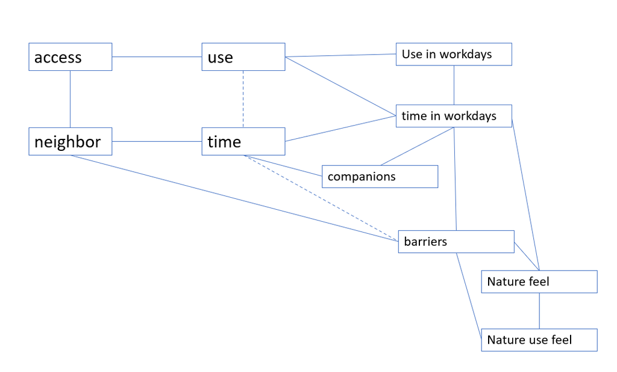

Relationship framework.

## 1 Access

a. What kind of outdoor/natural spaces do people have access to (Q2.3)?  
b.what quantity and level of diversity (ie higher quantity of spaces) of access do they have Q2.3)?

Access has 4 veriables in this survey:  
ACCESS TOTAL: total number of spaces a person can access  
OUTDOORS AT HOME: whether a person’s home has ‘private or shared yard’ and ‘deck balcony or patio’  
OUTDOORS NEAR HOME: total number of spaces that near home a person can access  
DIVERSITY NEAR HOME: whether a person can access 3 or more than 3 ourdoors near home spaces.

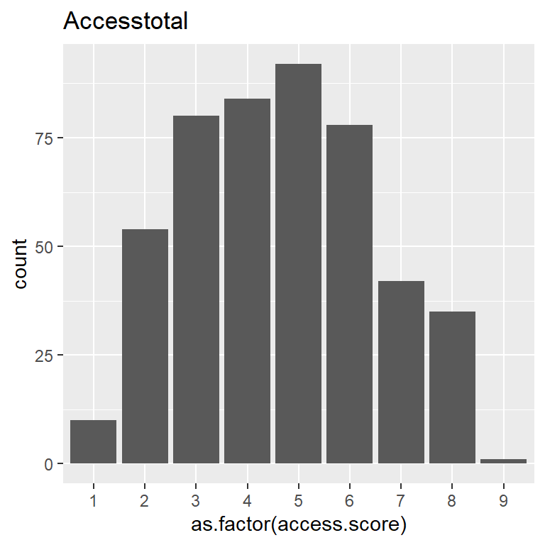

```r
Q2.3 %>%
  ggplot(mapping = aes(x=as.factor(access.score))) +
  geom_bar(stat="count",position='dodge')+
  ggtitle("Accesstotal")
```

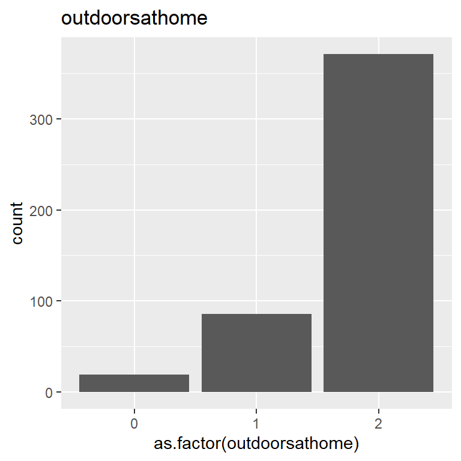

```r
Q2.3 %>%
  ggplot(mapping = aes(x=as.factor(outdoorsathome))) +
  geom_bar(stat="count",position='dodge') +
  ggtitle("outdoorsathome")
```

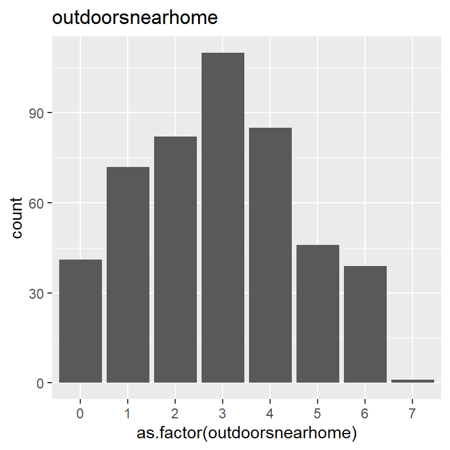

```r
Q2.3 %>%
  ggplot(mapping = aes(x=as.factor(outdoorsnearhome))) +
  geom_bar(stat="count",position='dodge') +
  ggtitle("outdoorsnearhome")
```

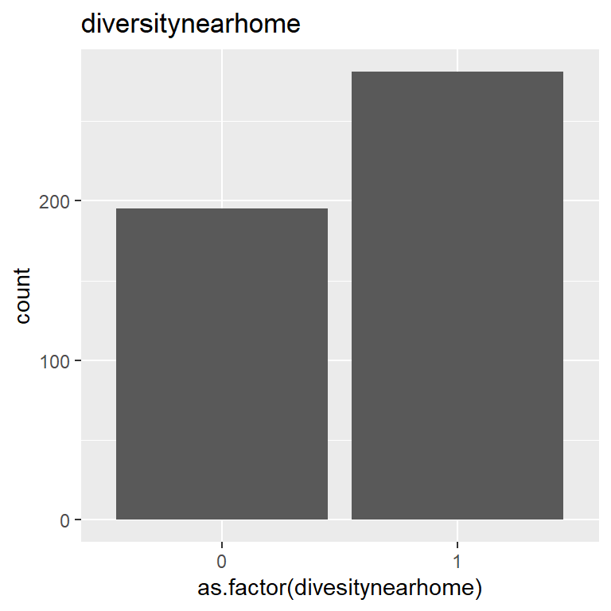

```r
Q2.3 %>%
  ggplot(mapping = aes(x=as.factor(divesitynearhome))) +
  geom_bar(stat="count",position='dodge')  +
  ggtitle("diversitynearhome")
```

c. Does access (multiple variables) correlate with type of home setting (Q7.7)  
The analysis part is below:  
Neighbortype: types of neigborhood a person lives. It has 5 levels. We can regard it as a categorical variable without any order or a ordinal variable which has an order from rural area to large city. The levels of this is shown in the first block below.  
The second block is the contingency table of neighbortype x accesstotal. The third block is CMH test on the contingency table. The first test cor treats both factors as ordered, the same as Spearman rank correlation; the second and third tests rmeans and cmeans treat columns and rows as ordered, the same as ANOVA tests. The last test general treats both factors as non-ordered and gives the Chi-2 test result.  
The rest blocks are contigency tables of each Access variable x neighbortype variable and their CMH test results accordingly.  
The last block is Sieve Diagram. Blue color means the cell has more count than expected if there is no correlation between the two factors. Red color means fewer counts. From this diagram, we could find the negative correlation between outdoorsathome and neighbortype.  
In summary, Outdoorsathome and neighbortype are highly correlated: urban neighborhood and number of types of ourdoorsathome are signifiacantly negative correlated.  
Other correlation relations are not very clear. We notice some cell has very few count values. However, even if we combine those cells together, i.e. we combine the last twe levels of neighbortype: small city and large city together, the significance level doesn’t change.

```r
df.chi<- df.chi %>%
    cbind("neighbortype"=as.factor(Q7.7_access$Q7.7)) %>%
    cbind("accessscore"= as.factor(Q7.7_access$access.score))
colnames(df.chi)[19]<-"accesstotal"

df.chi$neighbortype<-factor(df.chi$neighbortype,levels = c("Rural area","Small town or village (e.g., Trumansburg, Lansing)" ,"Suburb or just outside an urban center (e.g, Cayuga Heights, East Ithaca)","Smaller city or urban center (e.g. Ithaca, Elmira)" ,"Larger city or urban center (e.g., Syracuse, NYC)"), labels = c("Rurl","Smlltwn","Sbrb","Smllcty","Lrgcty"))
levels(df.chi$neighbortype)
```

```
## [1] "Rurl"    "Smlltwn" "Sbrb"    "Smllcty" "Lrgcty"
```

```r
Q1.1<-xtabs(~accesstotal + neighbortype,data=df.chi)
Q1.1
```

```
##            neighbortype
## accesstotal Rurl Smlltwn Sbrb Smllcty Lrgcty
##           1    2       3    1       2      1
##           2   13      10    8       9      1
##           3   18      25   14      17      6
##           4   22      18   10      29      2
##           5   25      19   12      29      1
##           6   15      23    9      24      0
##           7   16      10    3       8      0
##           8    8       9    5      11      0
##           9    0       0    1       0      0
```

```r
CMHtest(Q1.1)
```

```
## Cochran-Mantel-Haenszel Statistics for accesstotal by neighbortype
##
##                  AltHypothesis    Chisq Df     Prob
## cor        Nonzero correlation  0.41126  1 0.521333
## rmeans  Row mean scores differ  6.81779  8 0.556414
## cmeans  Col mean scores differ 10.04354  4 0.039701
## general    General association 38.00844 32 0.214520
```

```r
Q1.2<-xtabs(~outdoorsathome + neighbortype,data=df.chi)
Q1.2
```

```
##               neighbortype
## outdoorsathome Rurl Smlltwn Sbrb Smllcty Lrgcty
##              0    1       3    0       9      2
##              1   23      17   13      30      2
##              2   95      97   50      90      7
```

```r
CMHtest(Q1.2)
```

```
## Cochran-Mantel-Haenszel Statistics for outdoorsathome by neighbortype
##
##                  AltHypothesis   Chisq Df      Prob
## cor        Nonzero correlation  9.2899  1 0.0023042
## rmeans  Row mean scores differ 11.8447  2 0.0026789
## cmeans  Col mean scores differ 13.2074  4 0.0103057
## general    General association 20.7739  8 0.0077729
```

```r
Q1.3<-xtabs(~outdoorsnearhome + neighbortype,data=df.chi)
Q1.3_nlarge = Q1.3[-8,-5]
Q1.3
```

```
##                 neighbortype
## outdoorsnearhome Rurl Smlltwn Sbrb Smllcty Lrgcty
##                0   13      14    8       5      0
##                1   17      21   14      12      6
##                2   20      18    8      25      4
##                3   29      17   13      40      1
##                4   16      27   10      24      0
##                5   16      10    3      12      0
##                6    8      10    7      11      0
##                7    0       0    0       0      0
```

```r
Q1.3_nlarge
```

```
##                 neighbortype
## outdoorsnearhome Rurl Smlltwn Sbrb Smllcty
##                0   13      14    8       5
##                1   17      21   14      12
##                2   20      18    8      25
##                3   29      17   13      40
##                4   16      27   10      24
##                5   16      10    3      12
##                6    8      10    7      11
```

```r
CMHtest((Q1.3_nlarge))
```

```
## Cochran-Mantel-Haenszel Statistics for outdoorsnearhome by neighbortype
##
##                  AltHypothesis   Chisq Df     Prob
## cor        Nonzero correlation  1.8184  1 0.177504
## rmeans  Row mean scores differ  8.5031  6 0.203509
## cmeans  Col mean scores differ  4.5820  3 0.205088
## general    General association 28.1640 18 0.059602
```

```r
dtry<-as.data.frame(Q1.3_nlarge)
#ggplot(data = df.chi,aes(neighbortype,as.numeric(outdoorsnearhome)))+
#  geom_boxplot()
Q1.4<-xtabs(~divesitynearhome + neighbortype,data=df.chi)
CMHtest((Q1.4))
```

```
## Cochran-Mantel-Haenszel Statistics for divesitynearhome by neighbortype
##
##                  AltHypothesis    Chisq Df      Prob
## cor        Nonzero correlation  0.15436  1 0.6944008
## rmeans  Row mean scores differ  0.15436  1 0.6944008
## cmeans  Col mean scores differ 16.80459  4 0.0021094
## general    General association 16.80459  4 0.0021094
```

```r
Q1.2
```

```
##               neighbortype
## outdoorsathome Rurl Smlltwn Sbrb Smllcty Lrgcty
##              0    1       3    0       9      2
##              1   23      17   13      30      2
##              2   95      97   50      90      7
```

```r
CrossTable(Q1.2,prop.chisq = FALSE,prop.c=FALSE,format = "SPSS")
```

```
##
##    Cell Contents
## |-------------------------|
## |                   Count |
## |             Row Percent |
## |           Total Percent |
## |-------------------------|
##
## Total Observations in Table:  439
##
##                | neighbortype
## outdoorsathome |     Rurl  |  Smlltwn  |     Sbrb  |  Smllcty  |   Lrgcty  | Row Total |
## ---------------|-----------|-----------|-----------|-----------|-----------|-----------|
##              0 |        1  |        3  |        0  |        9  |        2  |       15  |
##                |    6.667% |   20.000% |    0.000% |   60.000% |   13.333% |    3.417% |
##                |    0.228% |    0.683% |    0.000% |    2.050% |    0.456% |           |
## ---------------|-----------|-----------|-----------|-----------|-----------|-----------|
##              1 |       23  |       17  |       13  |       30  |        2  |       85  |
##                |   27.059% |   20.000% |   15.294% |   35.294% |    2.353% |   19.362% |
##                |    5.239% |    3.872% |    2.961% |    6.834% |    0.456% |           |
## ---------------|-----------|-----------|-----------|-----------|-----------|-----------|
##              2 |       95  |       97  |       50  |       90  |        7  |      339  |
##                |   28.024% |   28.614% |   14.749% |   26.549% |    2.065% |   77.221% |
##                |   21.640% |   22.096% |   11.390% |   20.501% |    1.595% |           |
## ---------------|-----------|-----------|-----------|-----------|-----------|-----------|
##   Column Total |      119  |      117  |       63  |      129  |       11  |      439  |
## ---------------|-----------|-----------|-----------|-----------|-----------|-----------|
##
##
```

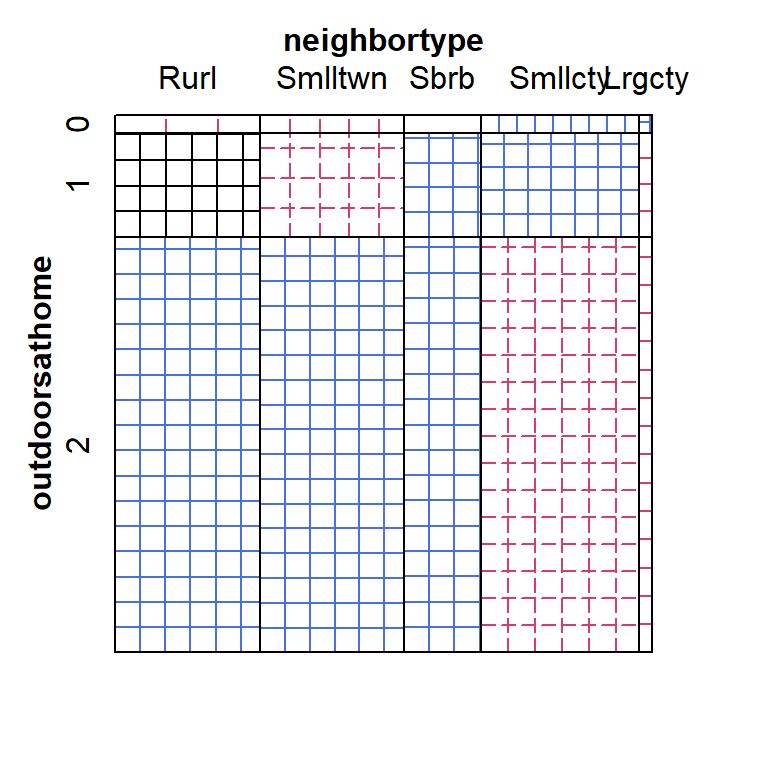

```r
sieve(Q1.2,shade = TRUE)
```

c1. Is access a moderator b/w use or time outdoors and neighborhood type?

For this question, I will check the moderator effect later, I am checking the a sub question here:

What is the relationship between time outdoors and neighborhood type?  
Time has two variables:  
Time.daysperweek: The level of days go outside every week. Time.hourspertime:  
The level of hours go outside each time.

There is correlation between time of ourtdoors perweek and neighborhood type. The Sieve diagram shows the pattern. We do Fisher test here as some cells have fewer than 5 counts. But no matter what test we do, no matter we treat the 2 factors as ordinal or catigorical variables, the correlations are significant.  
The analysis part is blow:

```r
Q2.1<-xtabs(~neighbortype+time.daysperweek,data = df.chi)
CMHtest(Q2.1)
```

```
## Cochran-Mantel-Haenszel Statistics for neighbortype by time.daysperweek
##
##                  AltHypothesis   Chisq Df      Prob
## cor        Nonzero correlation  9.6349  1 0.0019091
## rmeans  Row mean scores differ 12.3681  4 0.0148138
## cmeans  Col mean scores differ 15.3061  4 0.0041067
## general    General association 31.3150 16 0.0122624
```

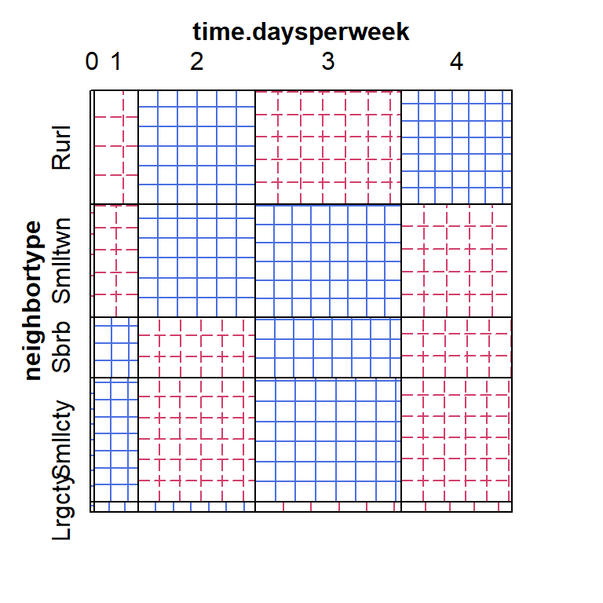

```r
sieve(Q2.1,shade = TRUE)
```

```r
Q2.2<-xtabs(~neighbortype+time.hourspertime,data = df.chi)
CMHtest(Q2.2)
```

```
## Cochran-Mantel-Haenszel Statistics for neighbortype by time.hourspertime
##
##                  AltHypothesis  Chisq Df      Prob
## cor        Nonzero correlation 10.446  1 0.0012289
## rmeans  Row mean scores differ 11.493  4 0.0215458
## cmeans  Col mean scores differ 11.681  3 0.0085599
## general    General association 23.022 12 0.0275438
```

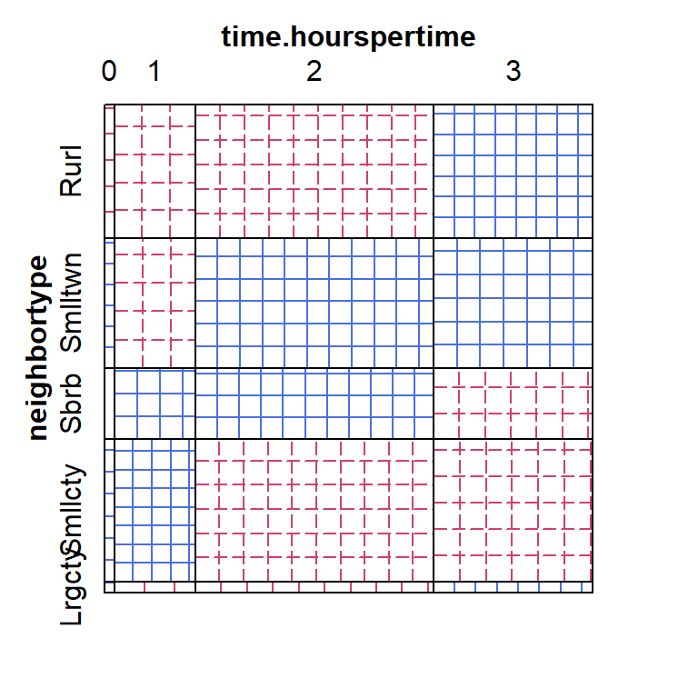

```r
sieve(Q2.2,shade=TRUE)
```

```r
#Q2_gender<-xtabs(~neighbortype+time.daysperweek+gender,data = df.chi)
#assocstats(Q2_gender)
#chisq.test(table(df.chi$neighbortype,df.chi$time.daysperweek))
fisher.test(Q2.1,simulate.p.value=TRUE,B=1e5)
```

```
##
##  Fisher's Exact Test for Count Data with simulated p-value (based on
##  1e+05 replicates)
##
## data:  Q2.1
## p-value = 0.02048
## alternative hypothesis: two.sided
```

```r
fisher.test(Q2.2,simulate.p.value = TRUE,B=1e5)
```

```
##
##  Fisher's Exact Test for Count Data with simulated p-value (based on
##  1e+05 replicates)
##
## data:  Q2.2
## p-value = 0.02621
## alternative hypothesis: two.sided
```

d. Does access at or near home OR diversity of spaces near home correlate to TOTAL TIME outdoors (in any of the 3 time periods)

The time.daysperweek is highly correlated with each variable of access.  
The analysis part is below:

```r
Q1.d1<-xtabs(~outdoorsathome+time.daysperweek,data = df.chi)
CMHtest(Q1.d1)
```

```
## Cochran-Mantel-Haenszel Statistics for outdoorsathome by time.daysperweek
##
##                  AltHypothesis  Chisq Df       Prob
## cor        Nonzero correlation 26.940  1 2.0989e-07
## rmeans  Row mean scores differ 26.978  2 1.3861e-06
## cmeans  Col mean scores differ 32.821  4 1.2997e-06
## general    General association 34.864  8 2.8304e-05
```

```r
Q1.d2<-xtabs(~outdoorsathome+time.hourspertime,data = df.chi)
CMHtest(Q1.d2)
```

```
## Cochran-Mantel-Haenszel Statistics for outdoorsathome by time.hourspertime
##
##                  AltHypothesis    Chisq Df     Prob
## cor        Nonzero correlation  0.16417  1 0.685343
## rmeans  Row mean scores differ  5.54795  2 0.062413
## cmeans  Col mean scores differ  4.39409  3 0.221934
## general    General association 12.66655  6 0.048648
```

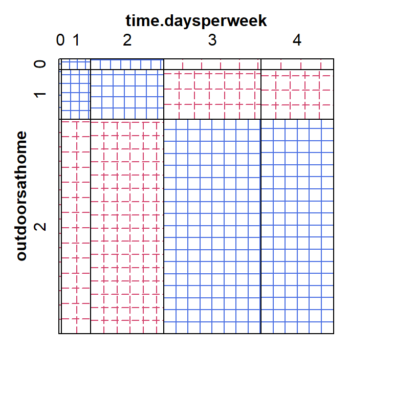

```r
sieve(Q1.d1,shade=TRUE)
```

```r
Q1.d3<-xtabs(~outdoorsnearhome+time.daysperweek,data = df.chi)
CMHtest(Q1.d3)
```

```
## Cochran-Mantel-Haenszel Statistics for outdoorsnearhome by time.daysperweek
##
##                  AltHypothesis  Chisq Df       Prob
## cor        Nonzero correlation 34.313  1 4.6934e-09
## rmeans  Row mean scores differ 36.364  7 6.1891e-06
## cmeans  Col mean scores differ 35.106  4 4.4182e-07
## general    General association 59.197 28 5.1519e-04
```

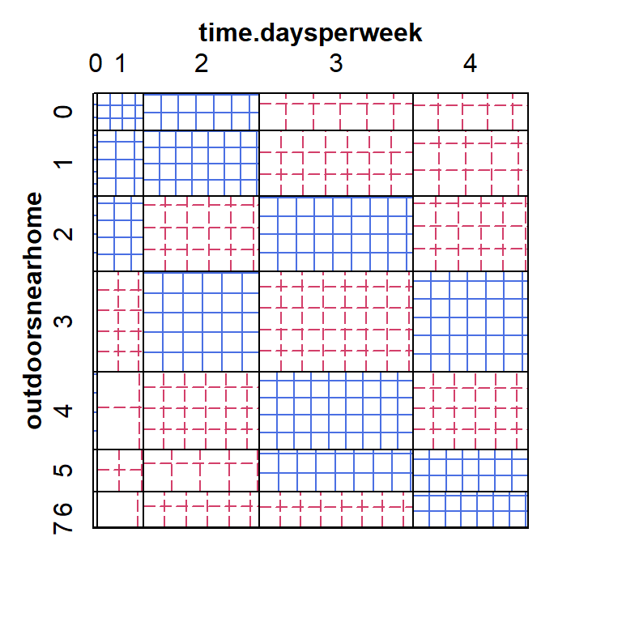

```r
sieve(Q1.d3,shade=TRUE)
```

```r
Q1.d4<-xtabs(~outdoorsnearhome+time.hourspertime,data = df.chi)
CMHtest(Q1.d4)
```

```
## Cochran-Mantel-Haenszel Statistics for outdoorsnearhome by time.hourspertime
##
##                  AltHypothesis   Chisq Df     Prob
## cor        Nonzero correlation  6.3219  1 0.011926
## rmeans  Row mean scores differ 11.1084  7 0.133961
## cmeans  Col mean scores differ  7.0117  3 0.071527
## general    General association 20.3277 21 0.500597
```

```r
Q1.d5<-xtabs(~divesitynearhome+time.daysperweek,data = df.chi)
CMHtest(Q1.d5)
```

```
## Cochran-Mantel-Haenszel Statistics for divesitynearhome by time.daysperweek
##
##                  AltHypothesis  Chisq Df       Prob
## cor        Nonzero correlation 26.072  1 3.2898e-07
## rmeans  Row mean scores differ 26.072  1 3.2898e-07
## cmeans  Col mean scores differ 26.581  4 2.4152e-05
## general    General association 26.581  4 2.4152e-05
```

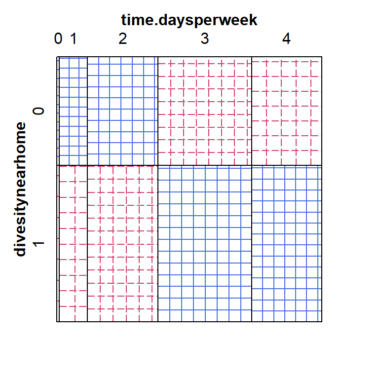

```r
sieve(Q1.d5,shade=TRUE)
```

```r
Q1.d6<-xtabs(~divesitynearhome+time.hourspertime,data = df.chi)
CMHtest(Q1.d6)
```

```
## Cochran-Mantel-Haenszel Statistics for divesitynearhome by time.hourspertime
##
##                  AltHypothesis  Chisq Df      Prob
## cor        Nonzero correlation 8.8189  1 0.0029812
## rmeans  Row mean scores differ 8.8189  1 0.0029812
## cmeans  Col mean scores differ 8.9873  3 0.0294609
## general    General association 8.9873  3 0.0294609
```

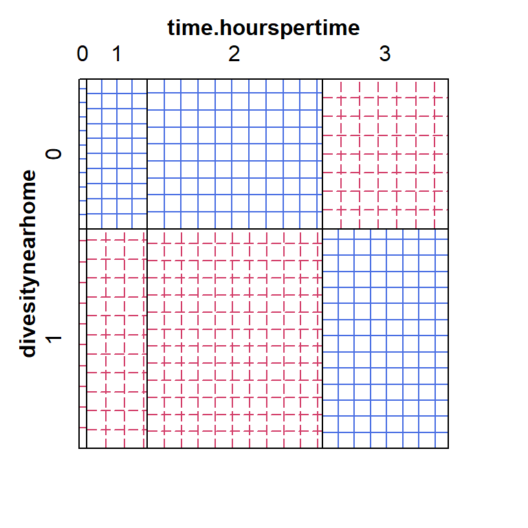

```r
sieve(Q1.d6,shade=TRUE)
```

## 2 Use

a. Use change pre to post covid within subjects significant?  
Use (Q2.4) include use score before: total number of outdoors places a person use before COVID;  
use score after: total number of outdoors places a person use during COVID.  
We use paired-test and treat the total number of types of place used as a continous variable. The test showed after COVID, space use is significantly less, but the significance is marginal. (0.19, p = 0.03).

```r
res <- t.test(Q2.4.score$use.score.before, Q2.4.score$use.score.after, paired = TRUE)
res
```

```
##
##  Paired t-test
##
## data:  Q2.4.score$use.score.before and Q2.4.score$use.score.after
## t = 2.1358, df = 475, p-value = 0.03321
## alternative hypothesis: true difference in means is not equal to 0
## 95 percent confidence interval:
##  0.01528802 0.36706492
## sample estimates:
## mean of the differences
##               0.1911765
```

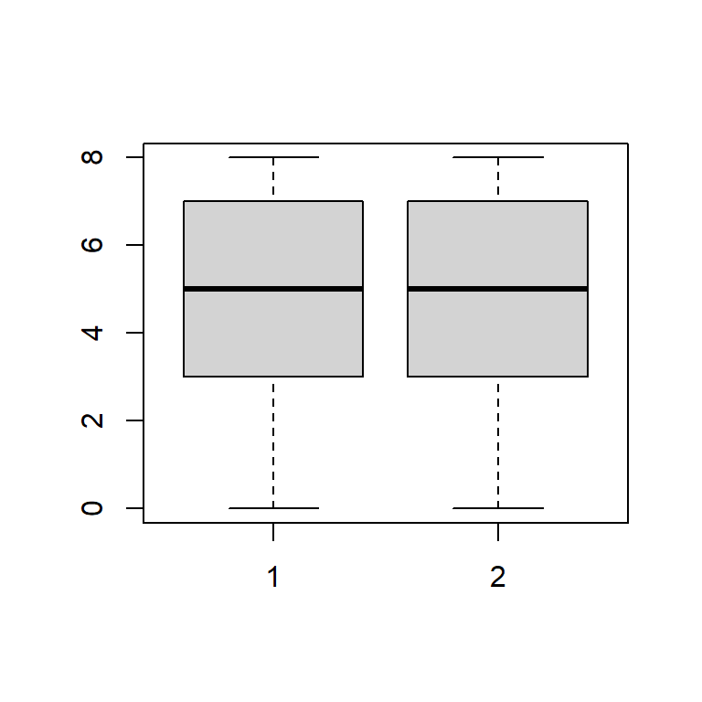

```r
boxplot(Q2.4.score$use.score.before, Q2.4.score$use.score.after)
```

b. Use change pre to post covid of different places in total significant?

I am not very confident in this analysis here. In the analysis below, I treat any person using each place or not follows the same distribution and add error bars for the total use of each place. However, I am not sure if this assumption is valid in this analysis.

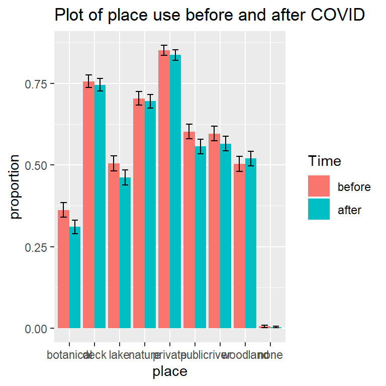

```r
Q2.4.sum %>%
  ggplot(mapping = aes(x=place,y=total/483,fill=factor(time,levels = c("before","after")))) +
  geom_bar(stat="identity",position='dodge')+
  geom_errorbar(aes(ymin=total/483-se, ymax=total/483+se), width=.5,
                position=position_dodge(.9)) +
  ylab("proportion")+
  guides(fill=guide_legend(title="Time"))+
  ggtitle("Plot of place use before and after COVID")
```

c. Does access relate to use?

Here, we test the correlation between the 4 access variables with total number of used places before and after- 8 correlations.  
We found all correlations are significant.

```r
Q2.c1<-xtabs(~df.chi$outdoorsathome+Q2.4.score$use.score.before)
Q2.c1
```

```
##                      Q2.4.score$use.score.before
## df.chi$outdoorsathome  0  1  2  3  4  5  6  7  8
##                     0  3  4  5  1  3  2  1  0  0
##                     1  6  6 11 20 15  8  8 12  0
##                     2  4  3 36 38 46 56 54 57 77
```

```r
CMHtest(Q2.c1)
```

```
## Cochran-Mantel-Haenszel Statistics for df.chi$outdoorsathome by Q2.4.score$use.score.before
##
##                  AltHypothesis   Chisq Df       Prob
## cor        Nonzero correlation  65.366  1 6.2210e-16
## rmeans  Row mean scores differ  65.541  2 5.8613e-15
## cmeans  Col mean scores differ  85.268  8 4.2298e-15
## general    General association 100.752 16 2.5037e-14
```

```r
Q2.c2<-xtabs(~df.chi$outdoorsathome+Q2.4.score$use.score.after)
CMHtest(Q2.c2)
```

```
## Cochran-Mantel-Haenszel Statistics for df.chi$outdoorsathome by Q2.4.score$use.score.after
##
##                  AltHypothesis  Chisq Df       Prob
## cor        Nonzero correlation 39.267  1 3.6962e-10
## rmeans  Row mean scores differ 40.435  2 1.6582e-09
## cmeans  Col mean scores differ 65.074  8 4.6669e-11
## general    General association 76.297 16 7.6801e-10
```

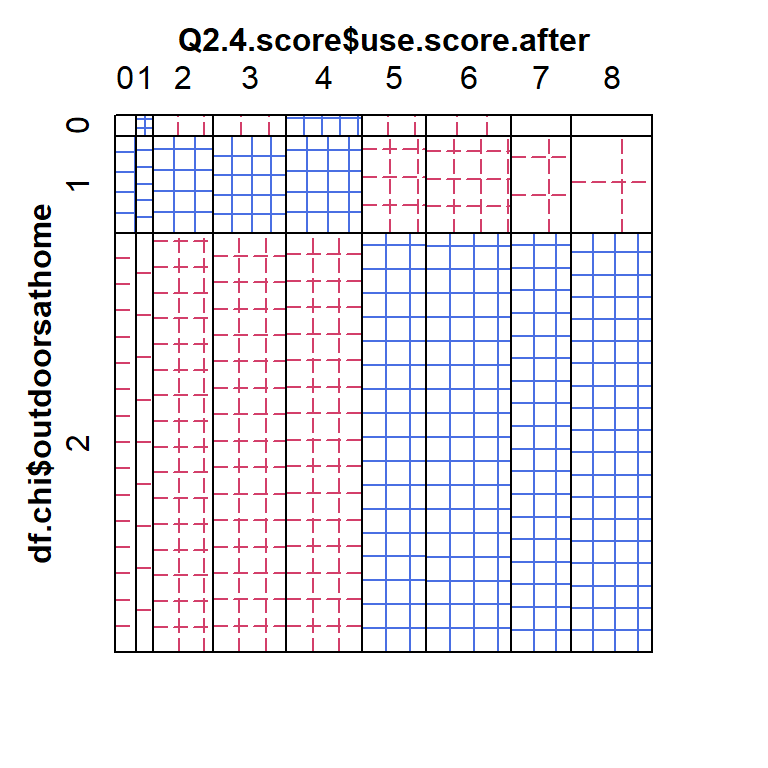

```r
sieve(Q2.c2,shade=TRUE)
```

```r
Q2.c3<-xtabs(~df.chi$outdoorsnearhome+Q2.4.score$use.score.before)
CMHtest(Q2.c3)
```

```
## Cochran-Mantel-Haenszel Statistics for df.chi$outdoorsnearhome by Q2.4.score$use.score.before
##
##                  AltHypothesis   Chisq Df       Prob
## cor        Nonzero correlation  75.938  1 2.9268e-18
## rmeans  Row mean scores differ  77.832  7 3.8089e-14
## cmeans  Col mean scores differ  93.120  8 1.0801e-16
## general    General association 242.194 56 5.2985e-25
```

```r
Q2.c4<-xtabs(~df.chi$outdoorsnearhome+Q2.4.score$use.score.after)
CMHtest(Q2.c4)
```

```
## Cochran-Mantel-Haenszel Statistics for df.chi$outdoorsnearhome by Q2.4.score$use.score.after
##
##                  AltHypothesis   Chisq Df       Prob
## cor        Nonzero correlation  79.068  1 6.0011e-19
## rmeans  Row mean scores differ  80.932  7 8.8901e-15
## cmeans  Col mean scores differ  97.009  8 1.7421e-17
## general    General association 258.141 56 1.0037e-27
```

```r
Q2.c5<-xtabs(~df.chi$divesitynearhome+Q2.4.score$use.score.before)
CMHtest(Q2.c5)
```

```
## Cochran-Mantel-Haenszel Statistics for df.chi$divesitynearhome by Q2.4.score$use.score.before
##
##                  AltHypothesis  Chisq Df       Prob
## cor        Nonzero correlation 43.382  1 4.5026e-11
## rmeans  Row mean scores differ 43.382  1 4.5026e-11
## cmeans  Col mean scores differ 64.828  8 5.2184e-11
## general    General association 64.828  8 5.2184e-11
```

```r
Q2.c6<-xtabs(~df.chi$divesitynearhome+Q2.4.score$use.score.after)
CMHtest(Q2.c6)
```

```
## Cochran-Mantel-Haenszel Statistics for df.chi$divesitynearhome by Q2.4.score$use.score.after
##
##                  AltHypothesis  Chisq Df       Prob
## cor        Nonzero correlation 50.478  1 1.2048e-12
## rmeans  Row mean scores differ 50.478  1 1.2048e-12
## cmeans  Col mean scores differ 74.939  8 5.0738e-13
## general    General association 74.939  8 5.0738e-13
```

```r
Q2.c7<-xtabs(~df.chi$accesstotal+Q2.4.score$use.score.before)
CMHtest(Q2.c7)
```

```
## Cochran-Mantel-Haenszel Statistics for df.chi$accesstotal by Q2.4.score$use.score.before
##
##                  AltHypothesis  Chisq Df       Prob
## cor        Nonzero correlation 104.57  1 1.5196e-24
## rmeans  Row mean scores differ 108.84  8 6.6066e-20
## cmeans  Col mean scores differ 114.74  8 4.0366e-21
## general    General association 383.84 64 3.8715e-47
```

```r
Q2.c8<-xtabs(~df.chi$accesstotal+Q2.4.score$use.score.after)
CMHtest(Q2.c8)
```

```
## Cochran-Mantel-Haenszel Statistics for df.chi$accesstotal by Q2.4.score$use.score.after
##
##                  AltHypothesis   Chisq Df       Prob
## cor        Nonzero correlation  97.476  1 5.4511e-23
## rmeans  Row mean scores differ  99.775  8 4.7467e-18
## cmeans  Col mean scores differ 113.919  8 5.9498e-21
## general    General association 334.685 64 2.6857e-38
```

d.Time outdoors since covid emerged (Q2.8) and in Fall 2019 (Q2.10)

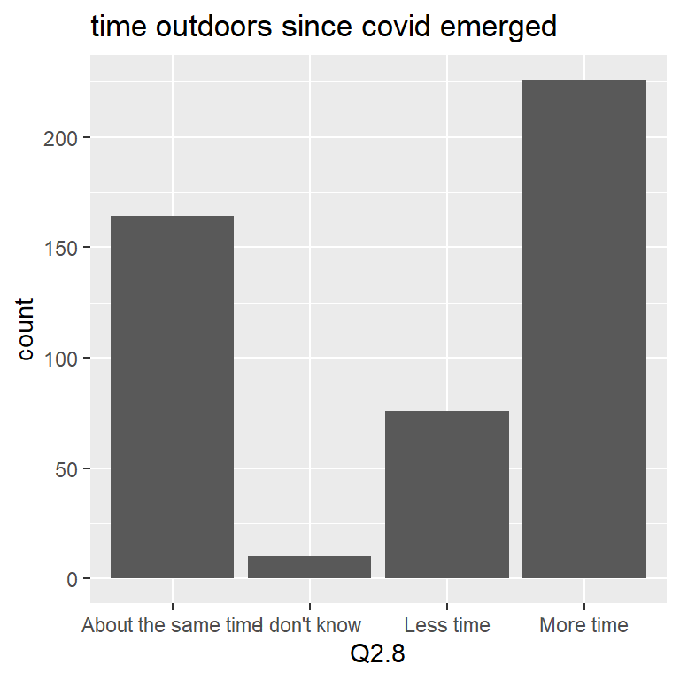

```r
raw %>%
  ggplot(mapping = aes(x=Q2.8))+
  geom_bar()+
  ggtitle("time outdoors since covid emerged")
```

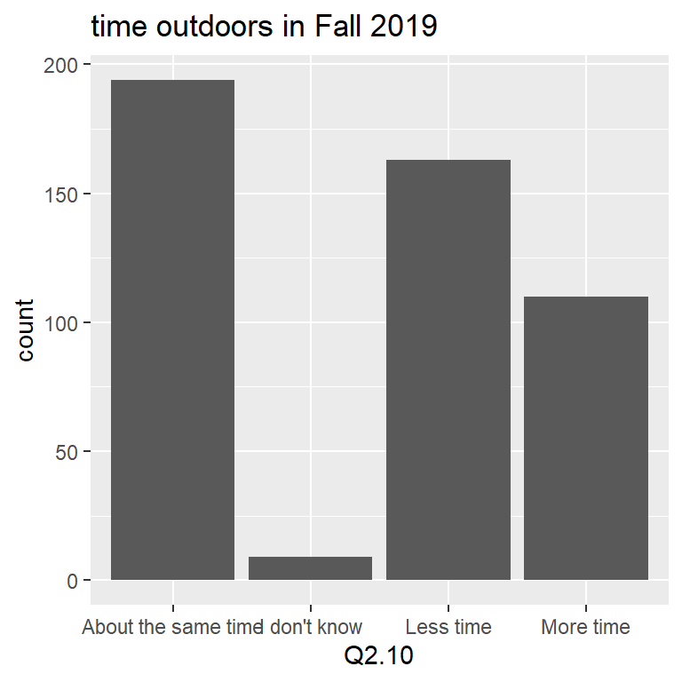

```r
raw %>%
  ggplot(mapping = aes(x=Q2.10))+
  geom_bar()+
  ggtitle("time outdoors in Fall 2019")
```

```r
CrossTable(raw$Q2.8,prop.chisq = FALSE,prop.c=FALSE,format = "SPSS")
```

```
##
##    Cell Contents
## |-------------------------|
## |                   Count |
## |             Row Percent |
## |-------------------------|
##
## Total Observations in Table:  476
##
##                     | About the same time  |        I don't know  |           Less time  |           More time  |
##                     |---------------------|---------------------|---------------------|---------------------|
##                     |                164  |                 10  |                 76  |                226  |
##                     |             34.454% |              2.101% |             15.966% |             47.479% |
##                     |---------------------|---------------------|---------------------|---------------------|
##
##
```

```r
CrossTable(raw$Q2.10,prop.chisq = FALSE,prop.c=FALSE,format = "SPSS")
```

```
##
##    Cell Contents
## |-------------------------|
## |                   Count |
## |             Row Percent |
## |-------------------------|
##
## Total Observations in Table:  476
##
##                     | About the same time  |        I don't know  |           Less time  |           More time  |
##                     |---------------------|---------------------|---------------------|---------------------|
##                     |                194  |                  9  |                163  |                110  |
##                     |             40.756% |              1.891% |             34.244% |             23.109% |
##                     |---------------------|---------------------|---------------------|---------------------|
##
##
```

e. Does time outdoors in workday and time in general correlate with any of the following:

1. Gender (Q7.2)
2. Neighborhood type (Q7.7)
3. Race (7.8)
4. Race category (new variable from 7.8)
5. HOME BARRIERS TOTAL (new variable)
6. People in the household : HOUSEHOLD TOTAL, CHILDREN, SENIORS or FAMILY
7. TOTAL COMPANIONS
8. FEEL ABOUT NATURE TOTAL
9. FEEL AFTER NATURE TOTAL

out_week: time outdoors in workday  
week_out: days outdoors in week  
out_time: time outdoor per time  
For the correlation table, the assumption is to treated all variables as ordinal variables. It makes sense for binary variables like gender, counts like total number, scale scores like feel about nature total; but NOT for categorical variables like race. For some variables like neighborhood type, it may make sense. The correlation is calculates as Spearman Correlation.  
But we need to be caustious on this correlation table as i am not very clear about the calculation now: some tests are not significant in chi2 test but significant here and I do not know the reason.

```r
df.cor<-as.data.frame(cbind(raw$Q5.2,raw$Q7.2,raw$Q7.3,raw$Q7.7,Q6.2$total_household,Q6.2$children,Q4.4$score,Q4.3$score,Q5.7$total_barriers,raw$Q2.5,raw$Q2.6))
colnames(df.cor)<-c("out_week","gender","workyrs","neighbor","household","children","naturefeel","nature_after_feel","barriers","week_out","out_time")
#round(cor(df.cor,use="pairwise.complete.obs"),digits =3)
ltm::rcor.test(df.cor,use="pairwise.complete.obs")
```

```
##
##                   out_week gender workyrs neighbor household children
## out_week           *****    0.018  0.058  -0.062   -0.001     0.019
## gender             0.718    *****  0.006  -0.006    0.066     0.045
## workyrs            0.232    0.894  *****  -0.300    0.141     0.050
## neighbor           0.197    0.897 <0.001   *****   -0.089    -0.047
## household          0.983    0.169  0.003   0.062    *****     0.687
## children           0.689    0.345  0.294   0.326   <0.001     *****
## naturefeel        <0.001    0.731  0.898   0.537    0.324     0.677
## nature_after_feel  0.065    0.005  0.799   0.891    0.061     0.178
## barriers          <0.001    0.508  0.001  <0.001    0.059     0.069
## week_out           0.001    0.943  0.001   0.033    0.042     0.848
## out_time           0.010    0.007  0.978   0.003    0.414     0.462
##                   naturefeel nature_after_feel barriers week_out out_time
## out_week           0.168      0.086            -0.267    0.150    0.121
## gender            -0.017     -0.134            -0.032    0.003    0.130
## workyrs            0.006      0.012            -0.158    0.155   -0.001
## neighbor          -0.030      0.007             0.184   -0.102   -0.141
## household          0.045      0.087            -0.087    0.093    0.038
## children           0.019      0.062            -0.083   -0.009    0.034
## naturefeel         *****      0.466            -0.055    0.398    0.149
## nature_after_feel <0.001      *****            -0.061    0.237    0.111
## barriers           0.234      0.187             *****   -0.072   -0.084
## week_out          <0.001     <0.001             0.116    *****    0.228
## out_time           0.001      0.017             0.069   <0.001    *****
##
## upper diagonal part contains correlation coefficient estimates
## lower diagonal part contains corresponding p-values
```

## 3 Work

a. Did staff typically spend time outdoors during the workday (Q5.2)?

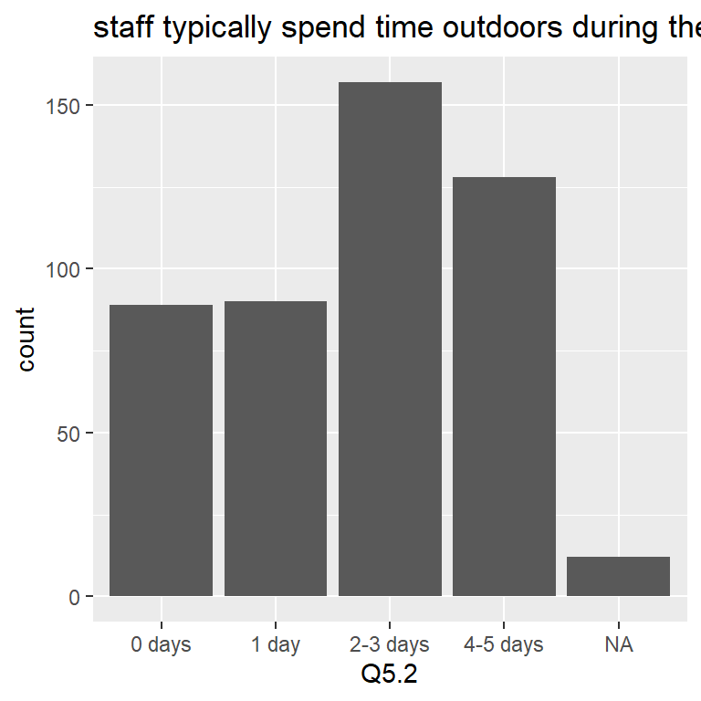

```r
raw0 %>%
  ggplot(mapping = aes(x=Q5.2))+
  geom_bar()+
  ggtitle("staff typically spend time outdoors during the workday")
```

```r
CrossTable(raw$Q5.2,prop.chisq = FALSE,prop.c=FALSE,format = "SPSS")
```

```
##
##    Cell Contents
## |-------------------------|
## |                   Count |
## |             Row Percent |
## |-------------------------|
##
## Total Observations in Table:  464
##
##           |        0  |        1  |        2  |        3  |
##           |-----------|-----------|-----------|-----------|
##           |       89  |       90  |      157  |      128  |
##           |   19.181% |   19.397% |   33.836% |   27.586% |
##           |-----------|-----------|-----------|-----------|
##
## Number of Missing Observations: 12 (2.521008%)
##
##
```

b. what did they typically do (Q5.6)

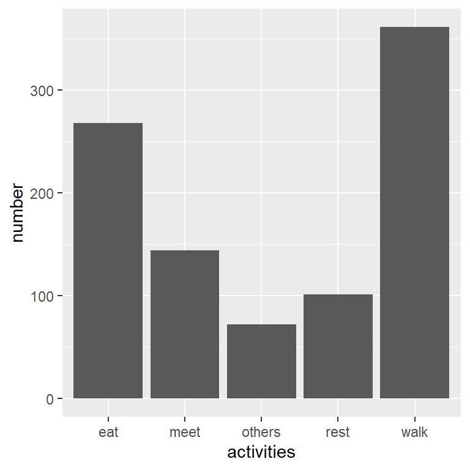

```r
Q5.6 %>%
  pivot_longer(eat:others,
               names_to = "activities",
               values_to = "number") %>%
  group_by(activities) %>%
  summarise_all(sum) %>%
  ggplot(mapping = aes(x=activities,y=number)) +
  geom_bar(stat="identity")
```

```r
Q5.6 %>%
  pivot_longer(eat:others,
               names_to = "activities",
               values_to = "number") %>%
  group_by(activities) %>%
  summarise_all(sum) %>%
  select(activities,number)
```

```
## # A tibble: 5 x 2
##   activities number
##   <chr>       <dbl>
## 1 eat           268
## 2 meet          144
## 3 others         72
## 4 rest          101
## 5 walk          361
```

c. Use in general and on campus correlation with:

1. gender
2. how long worked at Cornell (Q7.3)
3. type of employment (Q7.4 and 7.5)
4. work outdoors (Q7.6)
5. neighborhood type (7.7)
6. race (7.8)
7. race category (new variable from 7.8)
8. HOUSEHOLD TOTAL
9. CHILDREN
10. SENIORS
11. FAMILY
12. FEEL ABOUT NATURE TOTAL
13. FEEL AFTER NATURE TOTAL
14. WORK BARRIERS TOTAL (new variable)
15. TOTAL CAMPUS ACTIVITY

total_campusoutdoors: Q5.6 total places use on campus  
use.types.before: Q2.4 total places use before COVID  
use.types.after: Q2.4 total places use during COVID  
use.activities.before: Q3.2 total number of activities outdoors before COVID  
use.companions.before:3.3 total number of types of companions outdoors before COVID

```r
ltm::rcor.test(df.chi2,use="pairwise.complete.obs")
```

```
##
##                       total_campusoutdoors timeinworkday use.types.before
## total_campusoutdoors   *****                0.441         0.199
## timeinworkday         <0.001                *****         0.157
## use.types.before      <0.001                0.001         *****
## use.types.after        0.019                0.343        <0.001
## neighborhood           0.594                0.197         0.576
## gender                 0.552                0.718         0.353
## workyear               0.702                0.232         0.590
## use.activities.before <0.001               <0.001        <0.001
## use.activities.after   0.003                0.050        <0.001
## use.companions.before <0.001               <0.001        <0.001
## use.companions.after   0.019                0.285        <0.001
## time.daysperweek       0.294                0.001        <0.001
## time.hourspertime      0.687                0.010         0.035
## race1                  0.329                0.114         0.038
## race2                  0.313                0.319         0.135
##                       use.types.after neighborhood gender workyear
## total_campusoutdoors   0.108           0.025       -0.029 -0.018
## timeinworkday          0.044          -0.062        0.018  0.058
## use.types.before       0.619           0.027        0.045  0.026
## use.types.after        *****           0.081       -0.013 -0.071
## neighborhood           0.092           *****       -0.006 -0.300
## gender                 0.794           0.897        *****  0.006
## workyear               0.138          <0.001        0.894  *****
## use.activities.before  0.005           0.892        0.578  0.274
## use.activities.after  <0.001           0.130        0.050  0.031
## use.companions.before  0.071           0.053        0.199  0.894
## use.companions.after  <0.001           0.331        0.017  0.021
## time.daysperweek      <0.001           0.033        0.943  0.001
## time.hourspertime     <0.001           0.003        0.007  0.978
## race1                  0.051           0.256        0.007  0.092
## race2                  0.084           0.186        0.005  0.068
##                       use.activities.before use.activities.after
## total_campusoutdoors   0.270                 0.135
## timeinworkday          0.194                 0.091
## use.types.before       0.312                 0.192
## use.types.after        0.127                 0.275
## neighborhood          -0.006                -0.072
## gender                -0.027                -0.094
```

[output cut: 29 more lines]

```
## use.types.after        0.276            0.161             0.094  0.083
## neighborhood          -0.102           -0.141            -0.055 -0.064
## gender                 0.003            0.130            -0.130 -0.136
## workyear               0.155           -0.001             0.081  0.088
## use.activities.before  0.078            0.041             0.065  0.037
## use.activities.after   0.245            0.170             0.120  0.112
## use.companions.before  0.162            0.028             0.013 -0.005
## use.companions.after   0.181            0.097             0.118  0.100
## time.daysperweek       *****            0.228             0.124  0.108
## time.hourspertime     <0.001            *****             0.099  0.099
## race1                  0.010            0.039             *****  0.964
## race2                  0.025            0.040            <0.001  *****
##
## upper diagonal part contains correlation coefficient estimates
## lower diagonal part contains corresponding p-values
```

d. More or less time outdoors than when working from home?

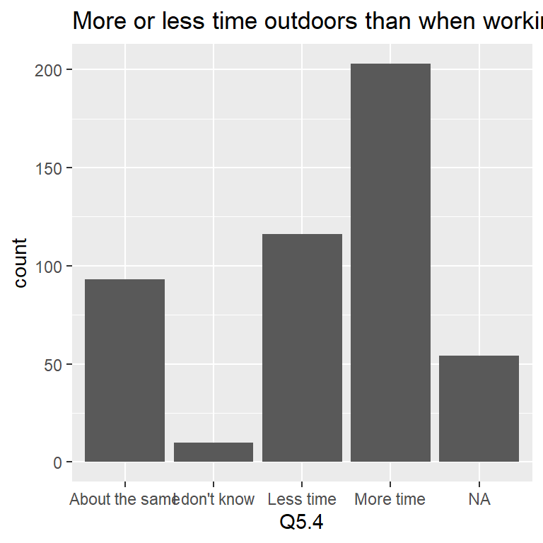

```r
raw %>%
  ggplot(mapping = aes(x=Q5.4))+
  geom_bar()+
  ggtitle("More or less time outdoors than when working from home")
```

```r
CrossTable(raw$Q5.4,prop.chisq = FALSE,prop.c=FALSE,format = "SPSS")
```

```
##
##    Cell Contents
## |-------------------------|
## |                   Count |
## |             Row Percent |
## |-------------------------|
##
## Total Observations in Table:  422
##
##                | About the same  |   I don't know  |      Less time  |      More time  |
##                |----------------|----------------|----------------|----------------|
##                |            93  |            10  |           116  |           203  |
##                |        22.038% |         2.370% |        27.488% |        48.104% |
##                |----------------|----------------|----------------|----------------|
##
## Number of Missing Observations: 54 (11.34454%)
##
##
```

e. More or less than on campus pre-covid (Q5.5)

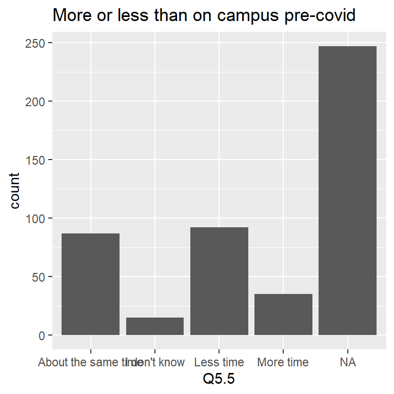

```r
raw %>%
  ggplot(mapping = aes(x=Q5.5))+
  geom_bar()+
  ggtitle("More or less than on campus pre-covid")
```

```r
CrossTable(raw$Q5.5,prop.chisq = FALSE,prop.c=FALSE,format = "SPSS")
```

```
##
##    Cell Contents
## |-------------------------|
## |                   Count |
## |             Row Percent |
## |-------------------------|
##
## Total Observations in Table:  229
##
##                     | About the same time  |        I don't know  |           Less time  |           More time  |
##                     |---------------------|---------------------|---------------------|---------------------|
##                     |                 87  |                 15  |                 92  |                 35  |
##                     |             37.991% |              6.550% |             40.175% |             15.284% |
##                     |---------------------|---------------------|---------------------|---------------------|
##
## Number of Missing Observations: 247 (51.89076%)
##
##
```

## 4 Barrier

a. Overview of barriers

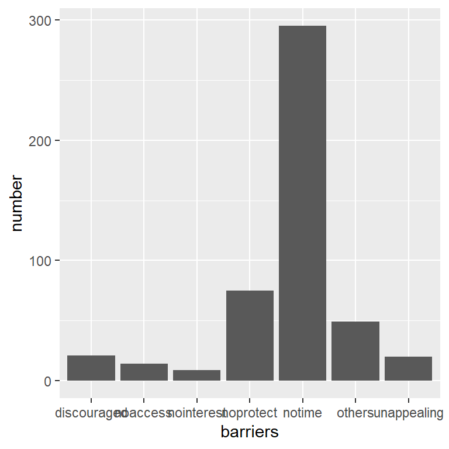

```r
Q5.7 %>%
  pivot_longer(nointerest:others,
               names_to = "barriers",
               values_to = "number") %>%
  group_by(barriers) %>%
  summarise_all(sum) %>%
  ggplot(mapping = aes(x=barriers,y=number)) +
  geom_bar(stat="identity")
```

```r
Q5.7.sum<-Q5.7 %>%
  pivot_longer(nointerest:others,
               names_to = "barriers",
               values_to = "number") %>%
  group_by(barriers) %>%
  summarise_all(sum) %>%
  select(barriers,number)

Q5.7.sum
```

```
## # A tibble: 7 x 2
##   barriers    number
##   <chr>        <dbl>
## 1 discouraged     21
## 2 noaccess        14
## 3 nointerest       9
## 4 noprotect       75
## 5 notime         295
## 6 others          49
## 7 unappealing     20
```

b. Time (both) is correlated with total barriers – very interesting – dig a bit deeper in relation to barriers – do barriers change by nbhd type? Gender? Attitudes towards nature?  
b1. Time.daysperweek and Time.hourspertime and total barriers:

Time.daysperweek NOT correlated with total barriers;  
Time.hourspertime and total barriers are correlated with marginal significance.

```r
Q4.b1<-xtabs(~df.chi$time.daysperweek+Q5.7$total_barriers)
CMHtest(Q4.b1)
```

```
## Cochran-Mantel-Haenszel Statistics for df.chi$time.daysperweek by Q5.7$total_barriers
##
##                  AltHypothesis   Chisq Df    Prob
## cor        Nonzero correlation  2.4764  1 0.11556
## rmeans  Row mean scores differ  3.3486  4 0.50128
## cmeans  Col mean scores differ  4.3826  5 0.49575
## general    General association 14.5581 20 0.80111
```

```r
Q4.b2<-xtabs(~df.chi$time.hourspertime+Q5.7$total_barriers)
CMHtest(Q4.b2)
```

```
## Cochran-Mantel-Haenszel Statistics for df.chi$time.hourspertime by Q5.7$total_barriers
##
##                  AltHypothesis   Chisq Df       Prob
## cor        Nonzero correlation  3.2975  1 0.06938743
## rmeans  Row mean scores differ 17.7751  3 0.00048942
## cmeans  Col mean scores differ  5.5299  5 0.35468346
## general    General association 24.2561 15 0.06087036
```

```r
Q4.b2
```

```
##                         Q5.7$total_barriers
## df.chi$time.hourspertime   0   1   2   3   4   5
##                        0   4   5   1   0   0   0
##                        1  13  36  19   6   2   1
##                        2  64 122  27  10   0   0
##                        3  42  87  25   6   1   0
```

```r
fisher.test(Q4.b2,simulate.p.value=TRUE,B=1e5)
```

```
##
##  Fisher's Exact Test for Count Data with simulated p-value (based on
##  1e+05 replicates)
##
## data:  Q4.b2
## p-value = 0.05598
## alternative hypothesis: two.sided
```

```r
CMHtest(Q4.b2[-1,c(-5,-6)])
```

```
## Cochran-Mantel-Haenszel Statistics for df.chi$time.hourspertime by Q5.7$total_barriers
##
##                  AltHypothesis   Chisq Df      Prob
## cor        Nonzero correlation  3.7277  1 0.0535179
## rmeans  Row mean scores differ  9.5076  2 0.0086188
## cmeans  Col mean scores differ  4.2012  3 0.2405390
## general    General association 11.7098  6 0.0687654
```

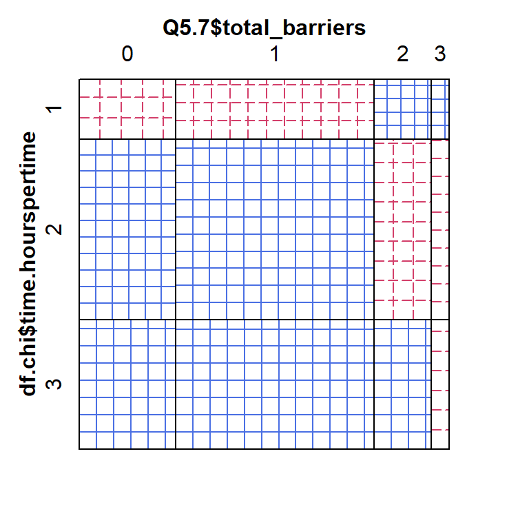

```r
sieve(Q4.b2[-1,c(-5,-6)],shade=TRUE)
```

b2. do barriers change by nbhd type? Gender? Attitudes towards nature?  
The significance tests are included below:

```r
Q4.b21<-xtabs(~df.chi$neighbortype+Q5.7$total_barriers)
Q4.b21
```

```
##                    Q5.7$total_barriers
## df.chi$neighbortype  0  1  2  3  4  5
##             Rurl    32 65 19  3  0  0
##             Smlltwn 40 57 17  3  0  0
##             Sbrb    18 33  6  4  2  0
##             Smllcty 18 72 26 11  1  1
##             Lrgcty   3  7  0  1  0  0
```

```r
CMHtest(Q4.b21)
```

```
## Cochran-Mantel-Haenszel Statistics for df.chi$neighbortype by Q5.7$total_barriers
##
##                  AltHypothesis  Chisq Df       Prob
## cor        Nonzero correlation 11.082  1 0.00087157
## rmeans  Row mean scores differ 18.680  4 0.00090813
## cmeans  Col mean scores differ 13.627  5 0.01815930
## general    General association 32.957 20 0.03410815
```

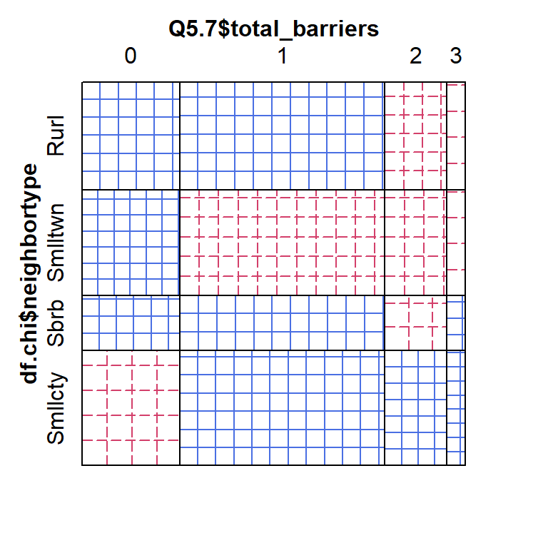

```r
sieve(Q4.b21[-5,c(-5,-6)],shade = TRUE)
```

```r
Q4.b22<-xtabs(~df.chi$gender+Q5.7$total_barriers)
Q4.b22
```

```
##              Q5.7$total_barriers
## df.chi$gender   0   1   2   3   4   5
##             0  91 192  56  19   3   1
##             1  18  40  10   3   0   0
```

```r
CMHtest(Q4.b22)
```

```
## Cochran-Mantel-Haenszel Statistics for df.chi$gender by Q5.7$total_barriers
##
##                  AltHypothesis   Chisq Df    Prob
## cor        Nonzero correlation 0.43952  1 0.50736
## rmeans  Row mean scores differ 0.43952  1 0.50736
## cmeans  Col mean scores differ 1.10070  5 0.95404
## general    General association 1.10070  5 0.95404
```

```r
Q4.b23<-xtabs(~df.cor$naturefeel+Q5.7$total_barriers)
Q4.b23
```

```
##                    Q5.7$total_barriers
## df.cor$naturefeel     0   1   2   3   4   5
##   0                   1   1   1   0   0   0
##   0.333333333333333   3   1   1   1   0   1
##   0.666666666666667   2   6   1   1   0   0
##   1                  17  24  12   3   0   0
##   1.33333333333333    0   3   0   0   0   0
##   1.66666666666667   12  27   7   3   0   0
##   2                   1   3   1   0   0   0
##   2.33333333333333    9  35   9   3   1   0
##   3                  77 154  41  11   2   0
```

```r
CMHtest(Q4.b23)
```

```
## Cochran-Mantel-Haenszel Statistics for df.cor$naturefeel by Q5.7$total_barriers
##
##                  AltHypothesis   Chisq Df       Prob
## cor        Nonzero correlation  1.1767  1 2.7802e-01
## rmeans  Row mean scores differ  5.7236  8 6.7816e-01
## cmeans  Col mean scores differ 11.5849  5 4.0940e-02
## general    General association 85.0158 40 4.3572e-05
```

```r
Q4.b24<-xtabs(~df.cor$nature_after_feel+Q5.7$total_barriers)
CMHtest(Q4.b24)
```

```
## Cochran-Mantel-Haenszel Statistics for df.cor$nature_after_feel by Q5.7$total_barriers
##
##                  AltHypothesis    Chisq Df      Prob
## cor        Nonzero correlation   2.7954  1 0.0945326
## rmeans  Row mean scores differ  29.7318 14 0.0083077
## cmeans  Col mean scores differ   3.6680  5 0.5981387
## general    General association 105.9426 70 0.0035981
```

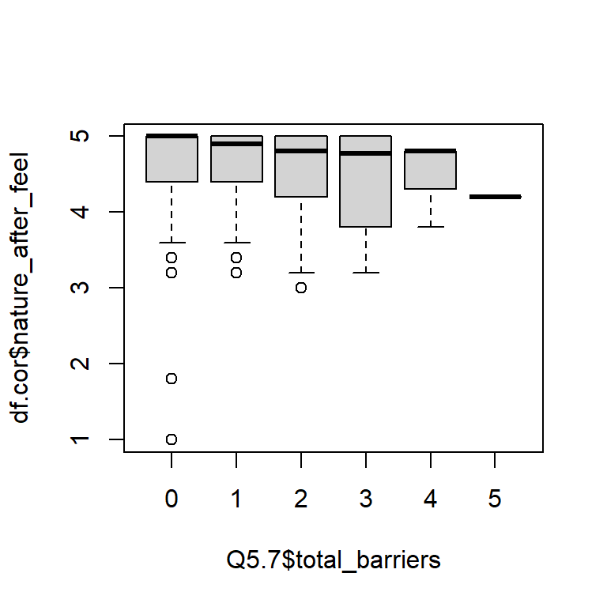

```r
boxplot(df.cor$nature_after_feel~Q5.7$total_barriers)
```

## 5 Other questions

a. Who do they spend time with in nature (at home and at work and for both pre and post covid) and how did it change – within and across subjects?

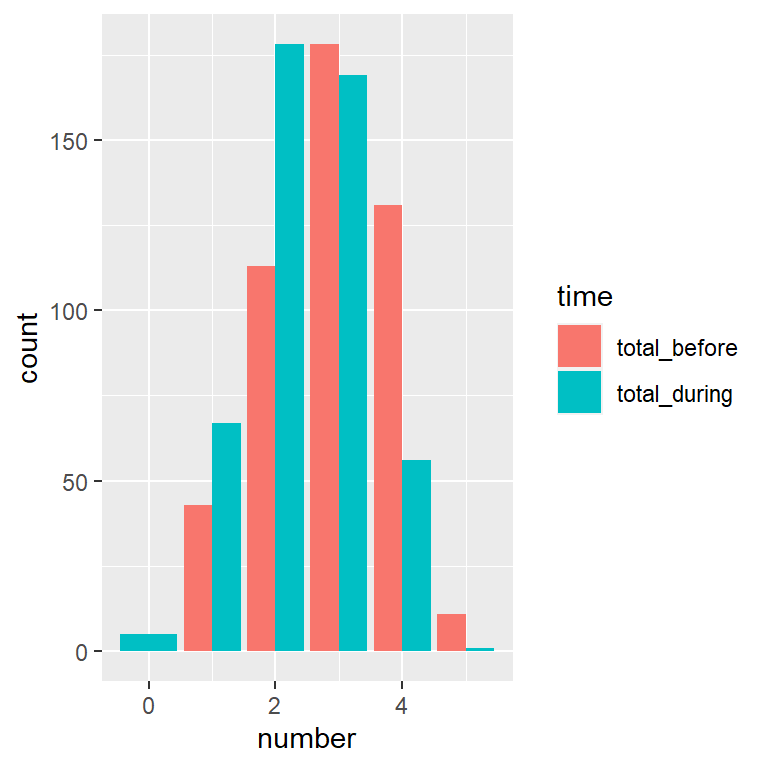

```r
Q3.3 %>%
  pivot_longer(total_before:total_during,
               names_to = "time",
               values_to = "number") %>%
  ggplot(mapping = aes(x=number,fill=time)) +
  geom_bar(stat="count",position='dodge')
```

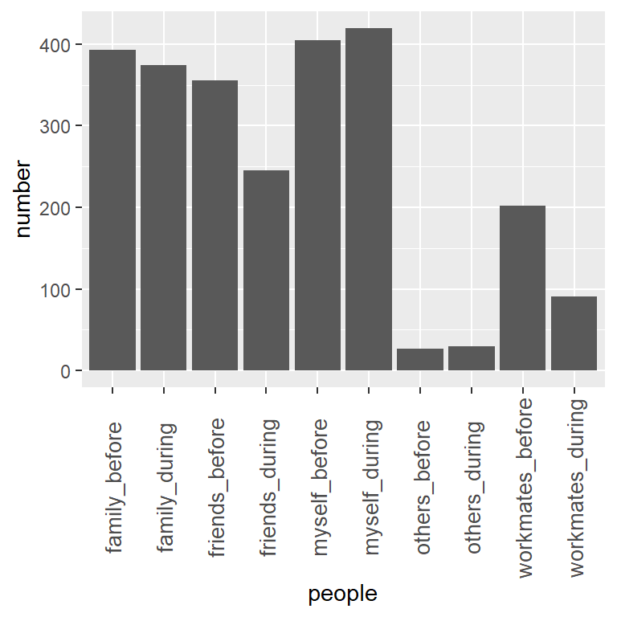

```r
Q3.3.sum<-Q3.3 %>%
  pivot_longer(myself_before:others_during,
               names_to = "people",
               values_to = "number") %>%
  group_by(people) %>%
  summarise_all(sum)

Q3.3.sum%>%
  ggplot(mapping = aes(x=people,y=number)) +
  geom_bar(stat="identity")+
  theme(axis.text.x = element_text(size=10,angle = 90,hjust=.5,vjust=.5,face="plain"))
```

```r
Q3.3.sum[,c(1,4)]
```

```
## # A tibble: 10 x 2
##    people           number
##    <chr>             <dbl>
##  1 family_before       393
##  2 family_during       374
##  3 friends_before      355
##  4 friends_during      245
##  5 myself_before       405
##  6 myself_during       419
##  7 others_before        27
##  8 others_during        30
##  9 workmates_before    202
## 10 workmates_during     91
```

```r
res2 <- t.test(Q3.3$total_before, Q3.3$total_during, paired = TRUE)
res2
```

```
##
##  Paired t-test
##
## data:  Q3.3$total_before and Q3.3$total_during
## t = 8.8435, df = 475, p-value < 2.2e-16
## alternative hypothesis: true difference in means is not equal to 0
## 95 percent confidence interval:
##  0.3643921 0.5725827
## sample estimates:
## mean of the differences
##               0.4684874
```

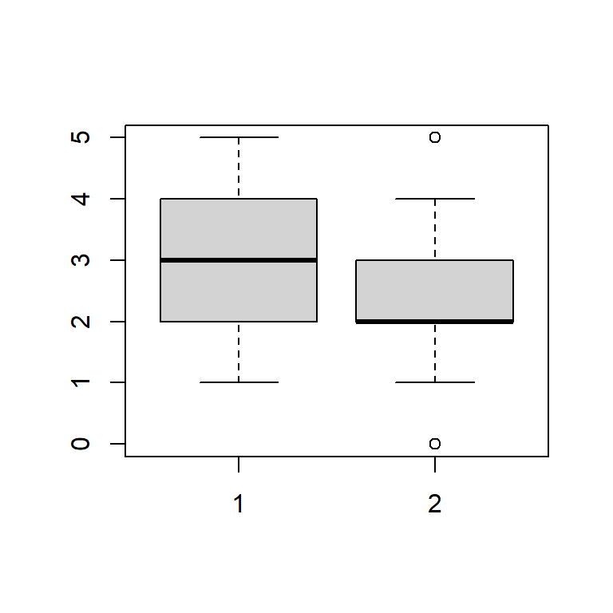

```r
boxplot(Q3.3$total_before, Q3.3$total_during)
```

```r
Q5.a<-xtabs(~Q3.3$family_before+ Q3.3$family_during)
Q5.a
```

```
##                   Q3.3$family_during
## Q3.3$family_before   0   1
##                  0  62  21
##                  1  40 353
```

```r
chisq.test(Q5.a)
```

```
##
##  Pearson's Chi-squared test with Yates' continuity correction
##
## data:  Q5.a
## X-squared = 165.62, df = 1, p-value < 2.2e-16
```

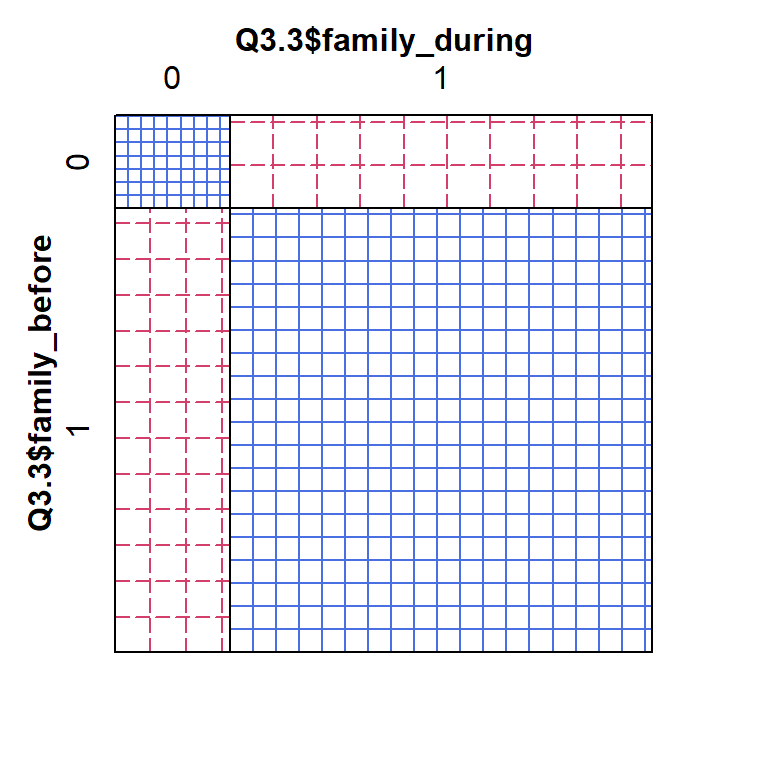

```r
sieve(Q5.a,shade = TRUE)
```

```r
Q5.a2<-xtabs(~Q3.3$myself_before+ Q3.3$myself_during)
Q5.a2
```

```
##                   Q3.3$myself_during
## Q3.3$myself_before   0   1
##                  0  39  32
##                  1  18 387
```

```r
chisq.test(Q5.a2)
```

```
##
##  Pearson's Chi-squared test with Yates' continuity correction
##
## data:  Q5.a2
## X-squared = 141.32, df = 1, p-value < 2.2e-16
```

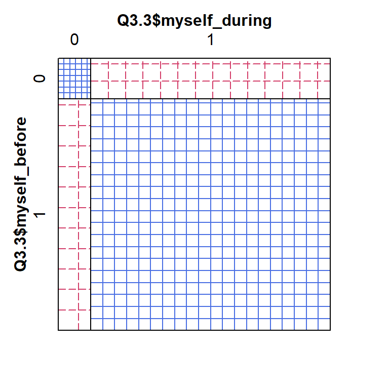

```r
sieve(Q5.a2,shade = TRUE)
```

```r
Q5.a3<-xtabs(~Q3.3$friends_before+ Q3.3$friends_during)
Q5.a3
```

```
##                    Q3.3$friends_during
## Q3.3$friends_before   0   1
##                   0  82  39
##                   1 149 206
```

```r
chisq.test(Q5.a3)
```

```
##
##  Pearson's Chi-squared test with Yates' continuity correction
##
## data:  Q5.a3
## X-squared = 23.02, df = 1, p-value = 1.603e-06
```

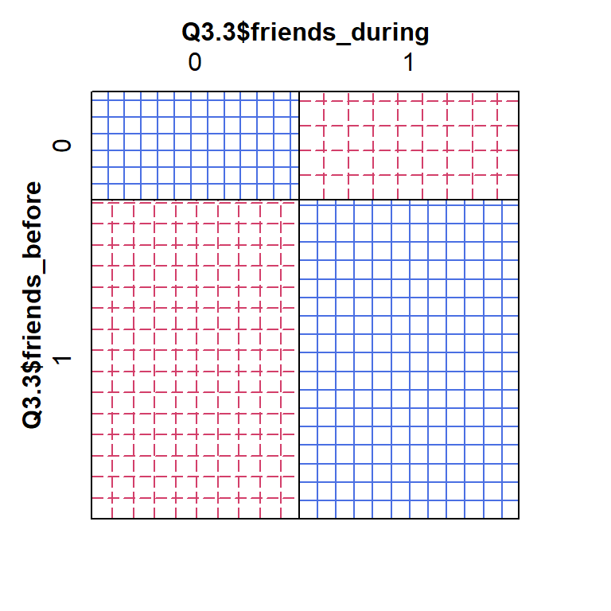

```r
sieve(Q5.a3,shade = TRUE)
```

```r
Q5.a4<-xtabs(~Q3.3$workmates_before+ Q3.3$workmates_during)
Q5.a4
```

```
##                      Q3.3$workmates_during
## Q3.3$workmates_before   0   1
##                     0 229  45
##                     1 156  46
```

```r
chisq.test(Q5.a4)
```

```
##
##  Pearson's Chi-squared test with Yates' continuity correction
##
## data:  Q5.a4
## X-squared = 2.6345, df = 1, p-value = 0.1046
```

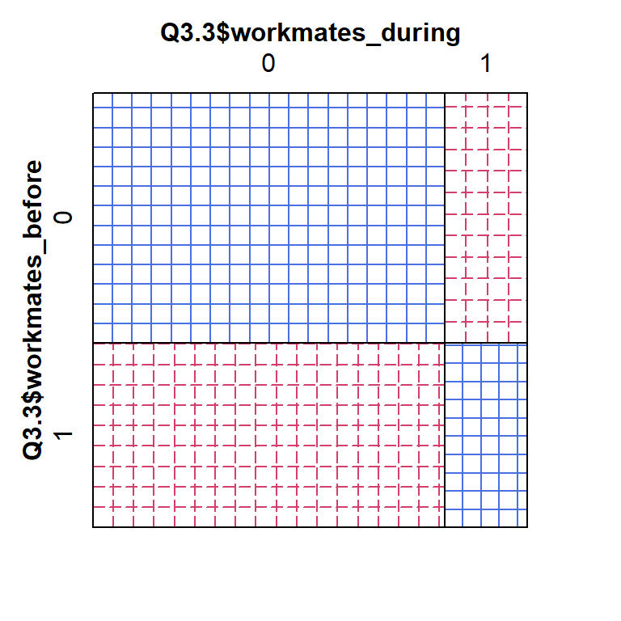

```r
sieve(Q5.a4,shade = TRUE)
```

b. What do they do outdoors (activities) - (at home and at work and for both pre and post covid) and how did it change – within and across subjects?